# Assignment 5

In this assignment, you'll scrape text from [The California Aggie](https://theaggie.org/) and then analyze the text.

The Aggie is organized by category into article lists. For example, there's a [Campus News](https://theaggie.org/campus/) list, [Arts & Culture](https://theaggie.org/arts/) list, and [Sports](https://theaggie.org/sports/) list. Notice that each list has multiple pages, with a maximum of 15 articles per page.

The goal of exercises 1.1 - 1.3 is to scrape articles from the Aggie for analysis in exercise 1.4.

**Exercise 1.1.** Write a function that extracts all of the links to articles in an Aggie article list. The function should:

- Have a parameter `url` for the URL of the article list.
- Have a parameter `page` for the number of pages to fetch links from. The default should be `1`.
- Return a list of aricle URLs (each URL should be a string).

Test your function on 2-3 different categories to make sure it works.

Hints:

- Be polite to The Aggie and save time by setting up [requests_cache](https://pypi.python.org/pypi/requests-cache) before you write your function.
- Start by getting your function to work for just 1 page. Once that works, have your function call itself to get additional pages.
- You can use [lxml.html](http://lxml.de/lxmlhtml.html) or [BeautifulSoup](https://www.crummy.com/software/BeautifulSoup/bs4/doc/) to scrape HTML. Choose one and use it throughout the entire assignment.

```python
import numpy as np
from urllib2 import Request, urlopen, HTTPError
from urlparse import urlunparse, urlparse
import json
import pandas as pd
from matplotlib import pyplot as plt
```

```python
import requests
import requests_cache
requests_cache.install_cache("cache")
```

```python
from bs4 import BeautifulSoup
import urllib
```

```python
def get_all_links(url, page = 1):
    all_article_links = []
    for i in range(1, page+1):
        each_page_url = url + 'page/' + str(i) + '/'
        r = urllib.urlopen(each_page_url).read()
        soup = BeautifulSoup(r)
        all_articles_onepage = soup.find_all("h2", class_ = "entry-title")
        for j in range(0, len(all_articles_onepage)):
            article_link = all_articles_onepage[j].find_all("a")[0].attrs["href"]
            all_article_links.append(article_link)
    return all_article_links
```

**Test for category campus with pages 60**

```python
get_all_links('https://theaggie.org/campus/', 60)
```

```
['https://theaggie.org/2017/02/23/academics-unite-in-peaceful-rally-against-immigration-ban/',
 'https://theaggie.org/2017/02/23/memorial-union-to-reopen-spring-quarter/',
 'https://theaggie.org/2017/02/23/asucd-president-alex-lee-vetoes-amendment-for-creation-of-judicial-council/',
 'https://theaggie.org/2017/02/22/senate-candidate-zaki-shaheen-withdraws-from-race/',
 'https://theaggie.org/2017/02/21/uc-davis-experiences-several-recent-hate-based-crimes/',
 'https://theaggie.org/2017/02/21/uc-president-selects-gary-may-as-new-uc-davis-chancellor/',
 'https://theaggie.org/2017/02/20/katehi-controversy-prompts-decline-of-uc-administrators-seeking-profitable-subsidiary-board-positions/',
 'https://theaggie.org/2017/02/20/asucd-senate-passes-resolution-submitting-comments-on-lrdp/',
 'https://theaggie.org/2017/02/20/uc-releases-2016-annual-report-on-sustainable-practices/',
 'https://theaggie.org/2017/02/19/uc-davis-global-affairs-holds-discussion-on-president-donald-trumps-executive-orders-on-immigration/',
 'https://theaggie.org/2017/02/19/trumps-immigration-ban-affects-uc-davis-community/',
 'https://theaggie.org/2017/02/17/uc-davis-students-participate-in-uc-wide-nodapl-day-of-action/',
 'https://theaggie.org/2017/02/17/uc-davis-holds-first-mental-health-conference/',
 'https://theaggie.org/2017/02/16/last-week-in-senate-6/',
 'https://theaggie.org/2017/02/16/2017-asucd-winter-elections-meet-the-candidates/',
 'https://theaggie.org/2017/02/13/pe-classes-may-charge-additional-fees/',
 'https://theaggie.org/2017/02/12/11-new-chancellor-fellows-honored-for-2016/',
 'https://theaggie.org/2017/02/12/muslim-students-respond-to-recent-political-events/',
 'https://theaggie.org/2017/02/12/sexcessful-campaign-launched-in-time-for-valentines-day/',
 'https://theaggie.org/2017/02/10/michael-chan-sworn-in-as-interim-senator/',
 'https://theaggie.org/2017/02/09/university-of-california-regents-meet-approve-first-tuition-raise-in-six-years/',
 'https://theaggie.org/2017/02/09/last-week-in-senate-5/',
 'https://theaggie.org/2017/02/09/uc-davis-receives-2-2-million-from-assembly-bill-2664/',
 'https://theaggie.org/2017/02/06/senator-bill-dodd-visits-uc-davis/',
 'https://theaggie.org/2017/02/05/ab-1887-prevents-use-of-state-funds-including-uc-funds-for-travel-to-states-with-anti-lgbt-laws/',
 'https://theaggie.org/2017/02/02/uc-system-hires-title-ix-coordinator/',
 'https://theaggie.org/2017/02/02/last-week-in-senate-4/',
 'https://theaggie.org/2017/02/02/action-jackson-famous-breeding-donkey-dies-at-29/',
 'https://theaggie.org/2017/02/02/asucd-senator-sam-park-resigns/',
 'https://theaggie.org/2017/01/31/uc-davis-graduate-creates-online-website-to-connect-students-with-professionals-for-career-advice/',
 'https://theaggie.org/2017/01/30/uc-davis-plans-to-bottle-student-wine-for-80/',
 'https://theaggie.org/2017/01/30/uc-davis-to-host-first-ever-mental-health-conference/',
 'https://theaggie.org/2017/01/29/uc-davis-sexual-violence-awareness-and-education-campaign-wins-award/',
 'https://theaggie.org/2017/01/29/uc-davis-study-abroad-secures-22000-in-grants-from-french-government/',
 'https://theaggie.org/2017/01/27/uc-regents-vote-to-raise-tuition-for-uc-campuses/',
 'https://theaggie.org/2017/01/26/former-white-house-speechwriter-comes-to-uc-davis/',
 'https://theaggie.org/2017/01/26/last-week-in-senate-3/',
 'https://theaggie.org/2017/01/26/davis-area-receives-nearly-eight-inches-of-rain-in-first-half-of-january/',
 'https://theaggie.org/2017/01/25/students-walk-out-of-classes-to-protest-trumps-climate-denial/',
 'https://theaggie.org/2017/01/24/uc-davis-ranked-most-sustainable-university-in-the-world/',
```

[output cut: 845 more lines]

```
 'https://theaggie.org/2012/11/29/news-in-brief-kdvs-and-aggietv-hold-live-forum-on-pepper-spray-incident/',
 'https://theaggie.org/2012/11/29/uc-davis-medical-center-dameron-hospital-to-expand-services/',
 'https://theaggie.org/2012/11/29/column-watts-legal-2/',
 'https://theaggie.org/2012/11/29/uc-campuses-take-on-challenge-to-reduce-food-waste/',
 'https://theaggie.org/2012/11/29/new-social-network-and-search-engine-comes-to-uc-campuses/',
 'https://theaggie.org/2012/11/29/uc-davis-greek-system-examines-safety-after-chico-state-death/',
 'https://theaggie.org/2012/11/28/uc-extends-fall-2013-application-deadline-for-students-impacted-by-hurricane-sandy/',
 'https://theaggie.org/2012/11/28/complaints-filed-against-asucd-senate-slates/',
 'https://theaggie.org/2012/11/28/uc-davis-students-rank-high-when-it-comes-to-honest-tea/',
 'https://theaggie.org/2012/11/28/highest-paid-uc-davis-faculty-members-from-medical-professional-programs/',
 'https://theaggie.org/2012/11/28/campus-chic-27/',
 'https://theaggie.org/2012/11/28/davis-and-asucd-plan-adopt-a-student-initiative/',
 'https://theaggie.org/2012/11/28/ask-doc-joe-and-katy-ann-8/',
 'https://theaggie.org/2012/11/27/news-in-brief-former-senator-mike-gravel-to-visit-campus-thursday/',
 'https://theaggie.org/2012/11/27/news-in-brief-uc-davis-stores-implement-customer-rewards-program/']
```

**Test with category arts&category with pages 30**

```python
get_all_links('https://theaggie.org/arts/', 30)
```

```
['https://theaggie.org/2017/02/23/harlows-nightclub-presents-khalid/',
 'https://theaggie.org/2017/02/21/late-night-eats-in-davis/',
 'https://theaggie.org/2017/02/21/2017-oscar-nominations-and-predictions/',
 'https://theaggie.org/2017/02/20/student-sounds-samantha-sipin/',
 'https://theaggie.org/2017/02/20/tv-revisited-the-office/',
 'https://theaggie.org/2017/02/19/uc-davis-theater-and-dance-presents-its-newest-comedy/',
 'https://theaggie.org/2017/02/19/twenty-one-pilots-emotional-roadshow-world-tour/',
 'https://theaggie.org/2017/02/16/a-night-under-the-stars/',
 'https://theaggie.org/2017/02/14/critically-acclaimed-stand-up-comic-brian-regan-to-perform-at-mondavi-center/',
 'https://theaggie.org/2017/02/13/burning-love-parody-of-the-bachelor/',
 'https://theaggie.org/2017/02/12/the-bachelor-engages-viewers-prompts-viewing-rituals/',
 'https://theaggie.org/2017/02/12/seven-movies-from-the-seven-countries-targeted-by-president-trumps-muslim-ban/',
 'https://theaggie.org/2017/02/12/the-best-of-times-and-the-worst-of-times-a-valentines-day-playlist/',
 'https://theaggie.org/2017/02/09/events-calendar-for-february/',
 'https://theaggie.org/2017/02/09/hopped-up-comedy-x-arrives-in-time-for-valentines-day-weekend/',
 'https://theaggie.org/2017/02/09/lantern-festival-the-beginning-of-the-year/',
 'https://theaggie.org/2017/02/07/top-three-places-to-eat-when-hungover/',
 'https://theaggie.org/2017/02/06/dance-dance/',
 'https://theaggie.org/2017/02/06/skams-universal-appeal/',
 'https://theaggie.org/2017/02/06/t-v-revisited-breaking-bad/',
 'https://theaggie.org/2017/02/02/headline-a-look-inside-kdvs/',
 'https://theaggie.org/2017/02/02/spoken-word-allows-for-expression-of-much-more-than-words/',
 'https://theaggie.org/2017/02/02/the-self-proclaimed-cure-for-racism/',
 'https://theaggie.org/2017/02/02/a-feast-for-the-ears-just-in-time-for-lunch/',
 'https://theaggie.org/2017/01/30/pronoun-highlights-struggles-of-transgender-youth/',
 'https://theaggie.org/2017/01/30/through-the-artists-eye-sammy-sanchez-monter/',
 'https://theaggie.org/2017/01/29/the-books-that-inspire-uc-davis-faculty/',
 'https://theaggie.org/2017/01/29/an-earful-introducing-andy-shauf/',
 'https://theaggie.org/2017/01/26/presenting-hasan-minhaj/',
 'https://theaggie.org/2017/01/26/who-is-u-s/',
 'https://theaggie.org/2017/01/26/waltz-in-magic/',
 'https://theaggie.org/2017/01/24/student-sounds-tempura/',
 'https://theaggie.org/2017/01/23/the-hidden-museums-of-uc-davis/',
 'https://theaggie.org/2017/01/23/aggie-style-watch-winter-edition/',
 'https://theaggie.org/2017/01/22/modern-love/',
 'https://theaggie.org/2017/01/22/la-la-land-review/',
 'https://theaggie.org/2017/01/20/old-holiday-allows-for-new-traditions/',
 'https://theaggie.org/2017/01/17/four-apps-to-help-foster-creativity-2/',
 'https://theaggie.org/2017/01/16/a-workout-playlist/',
 'https://theaggie.org/2017/01/15/fashion-trends-of-2017/',
```

[output cut: 365 more lines]

```
 'https://theaggie.org/2014/10/30/aggie-style-watch-halloween-costume-edition/',
 'https://theaggie.org/2014/10/30/the-morgue-hosts-halloween-spooktacular/',
 'https://theaggie.org/2014/10/30/aggieangelous-5/',
 'https://theaggie.org/2014/10/30/news-in-brief-design-project-to-combat-water-privatization/',
 'https://theaggie.org/2014/10/28/halloween-week-in-davis/',
 'https://theaggie.org/2014/10/28/davis-celebrates-day-of-the-dead/',
 'https://theaggie.org/2014/10/23/aggieangelous-4/',
 'https://theaggie.org/2014/10/23/arts-week-46/',
 'https://theaggie.org/2014/10/23/artist-review-james-ragan/',
 'https://theaggie.org/2014/10/23/regina-carter-to-take-mondavi-center-stage/',
 'https://theaggie.org/2014/10/21/holy-ghost-to-perform-at-uc-davis/',
 'https://theaggie.org/2014/10/21/the-art-theater-of-davis-presents-hay-fever/',
 'https://theaggie.org/2014/10/16/the-art-of-getting-by/',
 'https://theaggie.org/2014/10/16/featured-musician-kaz-mirblouk/',
 'https://theaggie.org/2014/10/16/aggieangelous-3/']
```

I define a function called get_all_links that takes main url and page and returns url for each article before that page. In this function I first get url for each page with string connecting and then get each article's url in that page with finding "entry-title" and "href" in html, finally I join url for articles in each page together. As a result, the function seems to work well according to the test results.

**Exercise 1.2.** Write a function that extracts the title, text, and author of an Aggie article. The function should:

- Have a parameter `url` for the URL of the article.
- For the author, extract the "Written By" line that appears at the end of most articles. You don't have to extract the author's name from this line.
- Return a dictionary with keys "url", "title", "text", and "author". The values for these should be the article url, title, text, and author, respectively.

For example, for [this article](https://theaggie.org/2017/02/14/project-toto-aims-to-address-questions-regarding-city-finances/) your function should return something similar to this:

```
{
    'author': u'Written By: Bianca Antunez \xa0\u2014\xa0city@theaggie.org',
    'text': u'Davis residents create financial model to make city\'s financial state more transparent To increase transparency between the city\'s financial situation and the community, three residents created a model called Project Toto which aims to improve how the city communicates its finances in an easily accessible design. Jeff Miller and Matt Williams, who are members of Davis\' Finance and Budget Commission, joined together with Davis entrepreneur Bob Fung to create the model plan to bring the project to the Finance and Budget Commission in February, according to Kelly Stachowicz, assistant city manager. "City staff appreciate the efforts that have gone into this, and the interest in trying to look at the city\'s potential financial position over the long term," Stachowicz said in an email interview. "We all have a shared goal to plan for a sound fiscal future with few surprises. We believe the Project Toto effort will mesh well with our other efforts as we build the budget for the next fiscal year and beyond." Project Toto complements the city\'s effort to amplify the transparency of city decisions to community members. The aim is to increase the understanding about the city\'s financial situation and make the information more accessible and easier to understand. The project is mostly a tool for public education, but can also make predictions about potential decisions regarding the city\'s financial future. Once completed, the program will allow residents to manipulate variables to see their eventual consequences, such as tax increases or extensions and proposed developments "This really isn\'t a budget, it is a forecast to see the intervention of these decisions," Williams said in an interview with The Davis Enterprise. "What happens if we extend the sales tax? What does it do given the other numbers that are in?" Project Toto enables users, whether it be a curious Davis resident, a concerned community member or a city leader, with the ability to project city finances with differing variables. The online program consists of the 400-page city budget for the 2016-2017 fiscal year, the previous budget, staff reports and consultant analyses. All of the documents are cited and accessible to the public within Project Toto. "It\'s a model that very easily lends itself to visual representation," Mayor Robb Davis said. "You can see the impacts of decisions the council makes on the fiscal health of the city." Complementary to this program, there is also a more advanced version of the model with more in-depth analyses of the city\'s finances. However, for an easy-to-understand, simplistic overview, Project Toto should be enough to help residents comprehend Davis finances. There is still more to do on the project, but its creators are hard at work trying to finalize it before the 2017-2018 fiscal year budget. "It\'s something I have been very much supportive of," Davis said. "Transparency is not just something that I have been supportive of but something we have stated as a city council objective [ ] this fits very well with our attempt to inform the public of our challenges with our fiscal situation." ',
    'title': 'Project Toto aims to address questions regarding city finances',
    'url': 'https://theaggie.org/2017/02/14/project-toto-aims-to-address-questions-regarding-city-finances/'
}
```

Hints:

- The author line is always the last line of the last paragraph.
- Python 2 displays some Unicode characters as `\uXXXX`. For instance, `\u201c` is a left-facing quotation mark. You can convert most of these to ASCII characters with the method call (on a string)

  ```
  .translate({ 0x2018:0x27, 0x2019:0x27, 0x201C:0x22, 0x201D:0x22, 0x2026:0x20 })
  ```

  If you're curious about these characters, you can look them up on [this page](http://unicode.org/cldr/utility/character.jsp), or read more about [what Unicode is](http://unicode.org/standard/WhatIsUnicode.html).

```python
def extract_article_information(url):
    r = urllib.urlopen(url).read()
    soup = BeautifulSoup(r)
    author = soup.find_all('div', itemprop = "articleBody")[0].find_all('p')[-1]
    content = soup.find_all('div', itemprop = "articleBody")[0].find_all(['p','div'])
    article_text = ""
    for i in range(0, len(content)-1):
        texts = content[i].get_text()
        article_text = article_text + texts
    text = article_text.translate({ 0x2018:0x27, 0x2019:0x27, 0x201C:0x22, 0x201D:0x22, 0x2026:0x20 })
    title = soup.find_all('h1', itemprop = "headline")[0].get_text()
    link = soup.find_all('link', rel = "canonical")[0].attrs['href']
    article_inform = {'author':author, 'text':text, 'title':title, 'url':link}
    return article_inform
```

```python
extract_article_information('https://theaggie.org/2017/02/21/2017-oscar-nominations-and-predictions/')
```

```
{'author': <p><i><span style="font-weight: 400;">Moonligh</span></i><span style="font-weight: 400;">t\u2019s strong contrasts and beautiful indigo-and-violet palette shine throughout the movie, and </span><i><span style="font-weight: 400;">La La Land</span></i><span style="font-weight: 400;"> stands…
 'text': u'La La Land expected to continue dominating awards season\nI look forward to the Academy Awards every year; the glitz and the glamour, the moving speeches and that special feeling of watching something universal, knowing that people all around the world are tuning in. But I admit that I al…
 'title': u'2017 Oscar Nominations and Predictions',
 'url': 'https://theaggie.org/2017/02/21/2017-oscar-nominations-and-predictions/'}
```

**Exercise 1.3.** Use your functions from exercises 1.1 and 1.2 to get a data frame of 60 [Campus News](https://theaggie.org/campus/) articles and a data frame of 60 [City News](https://theaggie.org/city/) articles. Add a column to each that indicates the category, then combine them into one big data frame.

The "text" column of this data frame will be your corpus for natural language processing in exercise 1.4.

```python
campus_link = get_all_links('https://theaggie.org/campus/', 4)
```

```python
campus_df = pd.DataFrame()
for i in range(0,len(campus_link)):
    dict_article = extract_article_information(campus_link[i])
    df_article = pd.DataFrame.from_dict(dict_article, orient='index')
    campus_df = campus_df.append(df_article.T, ignore_index=True)
campus_df
```

|  | url | text | title | author |
| --- | --- | --- | --- | --- |
| 0 | https://theaggie.org/2017/02/23/university-of-... | Wells Fargo faces fraud, predatory lending cha... | University of California, Davis City Council s... | Written by: Aaron Liss and Raul Castellanos —... |
| 1 | https://theaggie.org/2017/02/23/academics-unit... | Faculty, students recount personal tales of im... | Academics unite in peaceful rally against immi... | Abedifard said Sadeghi’s speech resonated with... |
| 2 | https://theaggie.org/2017/02/23/memorial-union... | Opening date pushed back to May 1Students have... | Memorial Union to reopen Spring Quarter | “As with any remodel project on a building tha... |
| 3 | https://theaggie.org/2017/02/23/asucd-presiden... | Veto included revision abandoning creation of ... | ASUCD President Alex Lee vetoes amendment for ... | Written by: Ivan Valenzuela — campus@theaggie.org |
| 4 | https://theaggie.org/2017/02/22/senate-candida... | Shaheen's name to remain on ballot, his votes ... | Senate candidate Zaki Shaheen withdraws from race | Written by: Alyssa Vandenberg — campus@theagg... |
| 5 | https://theaggie.org/2017/02/21/uc-davis-exper... | Students receive email warnings from UC Davis ... | UC Davis experiences several recent hate-based... | Written by: Aaron Liss — campus@theaggie.org |
| 6 | https://theaggie.org/2017/02/21/uc-president-s... | UC Board of Regents to vote on the appointment... | UC President selects Gary May as new UC Davis ... | Written by: Alyssa Vandenberg — campus@theagg... |
| 7 | https://theaggie.org/2017/02/20/katehi-controv... | Tighter policies require greater approval of o... | Katehi controversy prompts decline of UC admin... | The UC Davis and UC Office of the President’s ... |
| 8 | https://theaggie.org/2017/02/20/asucd-senate-p... | SR #7 asks university to increase capacity for... | ASUCD Senate passes resolution submitting comm... | Written by: Ivan Valenzuela — campus@theaggie... |
| 9 | https://theaggie.org/2017/02/20/uc-releases-20... | UC Davis leads in sustainability with largest ... | UC releases 2016 Annual Report on Sustainable ... | More information regarding the 2016 Annual Rep... |
| 10 | https://theaggie.org/2017/02/19/uc-davis-globa... | Speakers, including Interim Chancellor Ralph J... | UC Davis Global Affairs holds discussion on Pr... | “On a personal note, as in immigrant to this c... |
| 11 | https://theaggie.org/2017/02/19/trumps-immigra... | Executive order has immediate consequences for... | Trump’s immigration ban affects UC Davis commu... | “While maintaining the security of the nation’... |
| 12 | https://theaggie.org/2017/02/17/uc-davis-stude... | Student protesters march from MU flagpole to M... | UC Davis students participate in UC-wide #NoDA... | “Trump’s corporate colonial cabinet is hard at... |
| 13 | https://theaggie.org/2017/02/17/uc-davis-holds... | Conference entails full day of speakers, panel... | UC Davis holds first mental health conference | Written by: Jayashri Padmanabhan — campus@thea... |
| 14 | https://theaggie.org/2017/02/16/last-week-in-s... | Last week in SenateThe ASUCD Senate meeting wa... | Last week in Senate | The meeting adjourned at 6:59 p.m. \nWritten b... |
| 15 | https://theaggie.org/2017/02/16/2017-asucd-win... | Executive: Josh Dalavai and Adilla JamaludinIn... | 2017 ASUCD Winter Elections — Meet the Candidates | Written by: Alyssa Vandenberg and Emilie DeFaz... |
| 16 | https://theaggie.org/2017/02/14/shields-librar... | New showcase provides opportunity for students... | Shields Library hosts new exhibit for Davis ce... | Written by: Ivan Valenzuela — campus@theaggie.org |
| 17 | https://theaggie.org/2017/02/14/student-health... | Students promote fruit and vegetable meals via... | Student Health and Counseling Services hosts “... | This is the second time the SCHS has hosted th... |
| 18 | https://theaggie.org/2017/02/13/pe-classes-may... | New fees to pay for equipment replacementTo co... | PE classes may charge additional fees | “I’d think twice about taking a class,” Stucke... |
| 19 | https://theaggie.org/2017/02/12/11-new-chancel... | Recipients each rewarded $25,000 for researchU... | 11 new Chancellor Fellows honored for 2016 | “We honor the recipients and invite the donors... |
| 20 | https://theaggie.org/2017/02/12/muslim-student... | Muslim Student Association curates five-part D... | Muslim students respond to recent political ev... | “We wanted to target it towards non-Muslims wh... |
| 21 | https://theaggie.org/2017/02/12/sexcessful-cam... | Events to promote safe sexOn Feb. 1, Student H... | Sexcessful Campaign launched in time for Valen... | “One of the Sexcessful Campaign’s main focuses... |
| 22 | https://theaggie.org/2017/02/10/michael-chan-s... | Chan replaces former senator Sam ParkMichael C... | Michael Chan sworn in as interim senator | Written by: Alyssa Vandenberg — campus@theagg... |
| 23 | https://theaggie.org/2017/02/09/university-of-... | Regents approve tuition increase in 16-4 voteT... | University of California Regents meet, approve... | Written by: Kenton Goldsby — campus@theaggie.org |
| 24 | https://theaggie.org/2017/02/09/last-week-in-s... | Last week in SenateThe ASUCD Senate meeting wa... | Last week in Senate | Sandhu adjourned the meeting at 10 p.m. \nWrit... |
| 25 | https://theaggie.org/2017/02/09/uc-davis-recei... | Funding to expand innovation, entrepreneurship... | UC Davis receives $2.2 million from Assembly B... | “I find it important that we support research ... |
| 26 | https://theaggie.org/2017/02/06/senator-bill-d... | Davis College Democrats host Dodd for question... | Senator Bill Dodd visits UC Davis | “It gets students involved in politics,” Nash ... |
| 27 | https://theaggie.org/2017/02/05/ab-1887-preven... | Law to affect students selected to attend Nati... | AB 1887 prevents use of state funds, including... | Written by: Kenton Goldsby — campus@theaggie.org |
| 28 | https://theaggie.org/2017/02/02/uc-system-hire... | Kathleen Salvaty to oversee implementation of ... | UC system hires Title IX coordinator | Written by: Jayashri Padmanabhan — campus@thea... |
| 29 | https://theaggie.org/2017/02/02/last-week-in-s... | The second ASUCD Senate meeting of the new yea... | Last week in Senate | Written by: Jeanna Totah — campus@theaggie.org |
| 30 | https://theaggie.org/2017/02/02/action-jackson... | Action Jackson known for quality breeding, ext... | Action Jackson — famous breeding donkey — dies... | Written by: Demi Caceres — campus@theaggie.org |
| 31 | https://theaggie.org/2017/02/02/asucd-senator-... | Interim senator to be appointedOn Jan. 19, ASU... | ASUCD Senator Sam Park resigns | Written by: Alyssa Vandenberg — campus@theagg... |
| 32 | https://theaggie.org/2017/01/31/uc-davis-gradu... | Huttle helps students receive career advice fr... | UC Davis graduate creates online website to co... | Huttle is currently looking to hire student in... |
| 33 | https://theaggie.org/2017/01/30/uc-davis-plans... | Campus winery aims to remain environmentally s... | UC Davis plans to bottle student wine for $80 | Appelsmith and Block anticipate finalizing the... |
| 34 | https://theaggie.org/2017/01/30/uc-davis-to-ho... | Conference aims to destigmatize mental health,... | UC Davis to host first ever mental health conf... | Written by: Jayashri Padmanabhan — campus@thea... |
| 35 | https://theaggie.org/2017/01/29/uc-davis-sexua... | AMCP award recognizes excellence in marketing,... | UC Davis Sexual Violence Awareness and Educati... | “I really strongly believe in the domino effec... |
| 36 | https://theaggie.org/2017/01/29/uc-davis-study... | Awards geared toward students of color, studen... | UC Davis study abroad secures $22,000 in grant... | Students who are interested can learn more by ... |
| 37 | https://theaggie.org/2017/01/27/uc-regents-vot... | Tuition to increase by $336On Thursday, Jan. 2... | UC Regents vote to raise tuition for UC campuses | Written by: Alyssa Vandenberg — campus@theagg... |
| 38 | https://theaggie.org/2017/01/26/former-white-h... | Kevin Samy of Forbes' 2016 "30 under 30" list ... | Former White House speechwriter comes to UC Davis | Written by: Aaron Liss — campus@theaggie.org |
| 39 | https://theaggie.org/2017/01/26/last-week-in-s... | ASUCD held its first senate meeting of Winter ... | Last week in Senate | After ex-officio reports and elected officer r... |
| 40 | https://theaggie.org/2017/01/26/davis-area-rec... | Police chief provides information about safety... | Davis area receives nearly eight inches of rai... | Written by: Kenton Goldsby — campus@theaggie.org |
| 41 | https://theaggie.org/2017/01/25/students-walk-... | Protesters demand that Trump, UC system suppor... | Students walk out of classes to protest Trump’... | “We want to make a moral political statement t... |
| 42 | https://theaggie.org/2017/01/24/uc-davis-ranke... | GreenMetric names UC Davis the greenest univer... | UC Davis ranked most sustainable university in... | Written by: Aaron Liss — campus@theaggie.org |
| 43 | https://theaggie.org/2017/01/24/us-department-... | UC Davis-led institute one of five national tr... | US Department of Transportation awards $14 mil... | “As an agriculture school focused on being gre... |
| 44 | https://theaggie.org/2017/01/23/napolitano-to-... | Former plans paused in light of Katehi's resig... | Napolitano to reinforce tentative plans to exp... | Written by: Lindsay Floyd — campus@theaggie.org |
| 45 | https://theaggie.org/2017/01/23/former-chancel... | Feminist Research Institute nominates Linda Ka... | Former chancellor turns down feminist leadersh... | Written by: Ivan Valenzuela — campus@theaggie.org |
| 46 | https://theaggie.org/2017/01/22/sierra-nevada-... | The first endowed brewer will be Joe WilliamsS... | Sierra Nevada Brewing owners gift $2 million t... | Written by: Yvonne Leong — campus@theaggie.org |
| 47 | https://theaggie.org/2017/01/22/interim-chance... | 250 institutions ask new administration to add... | Interim Chancellor Hexter, UC leaders sign let... | Written by: Jayashri Padmanabhan — campus@thea... |
| 48 | https://theaggie.org/2017/01/22/california-sch... | Higher education leaders stand by undocumented... | California schools press Donald Trump to conti... | Written by: Jeanna Totah — campus@theaggie.org |
| 49 | https://theaggie.org/2017/01/22/uc-wide-walkou... | UC Student Workers Union hosts walkout, teach-... | UC-wide walkout, teach-ins on Trump’s inaugura... | Written by: Aaron Liss — campus@theaggie.org |
| 50 | https://theaggie.org/2017/01/20/protests-erupt... | Some activists in favor of Yiannopoulos, other... | Protests erupt at Milo Yiannopoulos event | Written By: Lindsay Floyd — campus@theaggie.org |
| 51 | https://theaggie.org/2017/01/20/student-organi... | Speakers CeCe McDonald and Franchesca Ramsey k... | Student organizers host “Change/The Conversati... | Written by: Kenton Goldsby — campus@theaggie.org |
| 52 | https://theaggie.org/2017/01/19/uc-president-j... | Napolitano expected to leave hospital soon, ma... | UC President Janet Napolitano hospitalized | Written by: Lindsay Floyd — campus@theaggie.org |
| 53 | https://theaggie.org/2017/01/17/uc-davis-appoi... | Former interim chief of nursing and patient ca... | UC Davis appoints new chief of nursing and pat... | Written by: Yvonne Leong — campus@theaggie.org |
| 54 | https://theaggie.org/2017/01/16/student-regent... | UC Board of Regents creates position of studen... | Student regent recruitment for the 2018-2019 s... | Written by: Demi Caceres — campus@theaggie.org |
| 55 | https://theaggie.org/2017/01/15/russell-boulev... | LRDP update preserves Russell Boulevard fields... | Russell Boulevard intramural fields withdrawn ... | “[I have] lived in Davis off and on my whole l... |
| 56 | https://theaggie.org/2017/01/15/ucs-receive-re... | Increase in applications brings more diverse p... | UCs receive record-breaking number of applicants | “The UCs [offer] a very good education, so I t... |
| 57 | https://theaggie.org/2017/01/14/davis-college-... | Yiannopoulos explains event's cancellation, ma... | Davis College Republicans club leads protest a... | Written by: Alyssa Vandenberg — campus@theagg... |
| 58 | https://theaggie.org/2017/01/13/breaking-news-... | Protests against far-right conservative Milo Y... | BREAKING NEWS: Milo Yiannopoulos event cancelled | More information to come.\nWritten by: Alyssa ... |
| 59 | https://theaggie.org/2017/01/12/martin-shkreli... | KMERON [CC BY 2.0] / FLICKRInterim Chancellor ... | Martin Shkreli to join Milo Yiannopoulos at UC... | Written by: Alyssa Vandenberg — campus@theagg... |

```python
city_link = get_all_links('https://theaggie.org/city/', 4)
city_df = pd.DataFrame()
for i in range(0,len(city_link)):
    dict_article = extract_article_information(city_link[i])
    df_article = pd.DataFrame.from_dict(dict_article, orient='index')
    city_df = city_df.append(df_article.T, ignore_index=True)
city_df
```

|  | url | text | title | author |
| --- | --- | --- | --- | --- |
| 0 | https://theaggie.org/2017/02/23/davis-whole-fo... | Local Whole Foods closes Feb. 12After five yea... | Davis’ Whole Foods Market shuts down | “It just feels out of place, not having a Whol... |
| 1 | https://theaggie.org/2017/02/23/protest-agains... | Demonstrations take place at hundreds of Plann... | Protest against Planned Parenthood in Woodland... | Written By: Anya Rehon — city@theaggie.org |
| 2 | https://theaggie.org/2017/02/23/daviss-histori... | California Redevelopment Agencies require Davi... | Davis’s Historic City Hall building to be put ... | “We have to demonstrate to the state that we a... |
| 3 | https://theaggie.org/2017/02/21/davis-stands-w... | Davis residents show solidarity in wake of tra... | Davis stands with Muslim residents | “After you reach out, get involved,” Mansuri s... |
| 4 | https://theaggie.org/2017/02/20/city-of-davis-... | CalRecycle donates $197,851The City of Davis w... | City of Davis awarded funds for new recycling ... | To help the campus reach its goal, Vang recomm... |
| 5 | https://theaggie.org/2017/02/19/police-logs-12/ | The world is a weird placeFeb. 6"Chronic phone... | Police Logs | “Chicken trying to cross the road, loitering a... |
| 6 | https://theaggie.org/2017/02/16/city-of-davis-... | Mayor Robb Davis reaffirms that the City of Da... | City of Davis to retain sanctuary city status | Written by: Raul Castellanos Jr — city@theaggi... |
| 7 | https://theaggie.org/2017/02/15/suspect-in-dav... | Davis resident Lauren Kirk-Coehlo arrested in ... | Suspect in Davis Islamic Center vandalism arre... | “On behalf of the Muslim community in Davis, w... |
| 8 | https://theaggie.org/2017/02/14/project-toto-a... | Davis residents create financial model to make... | Project Toto aims to address questions regardi... | Written By: Bianca Antunez — city@theaggie.org |
| 9 | https://theaggie.org/2017/02/13/police-logs-11/ | Something smells fishyJan. 29 "Loud music or T... | Police Logs | “Ongoing issue with parents parking in the whi... |
| 10 | https://theaggie.org/2017/02/12/news-in-brief-... | Davis Cemetery District hosts fundraiser with ... | News in Brief: A Valentine’s Day for everybody | *Name changed for anonymity \nWritten By: Dian... |
| 11 | https://theaggie.org/2017/02/06/the-musical-tr... | Davis Sunrise Rotary Club grant benefits Alzhe... | The musical train to memory lane | Written by: Kaelyn Tuermer-Lee — city@theaggie... |
| 12 | https://theaggie.org/2017/02/05/police-logs-10/ | False alarm, false alarmJan. 22"Female was run... | Police Logs | Written by: Kaelyn Tuermer-Lee — city@theaggie... |
| 13 | https://theaggie.org/2017/02/05/davis-owls-fac... | Burrowing Owl Preservation Society sues City o... | Davis owls face eviction at Marriott Residence... | Written By: Bianca Antunez — city@theaggie.org |
| 14 | https://theaggie.org/2017/02/02/davis-celebrat... | The City of Davis hosts festivities in honor o... | Davis Celebrates MLK Day | Written By: Dianna Rivera – city@theaggie.org |
| 15 | https://theaggie.org/2017/02/02/local-author-c... | Douglas L. Waterman publishes 'It Only Hurts W... | Local author, cyclist rides 2,300 miles | Written by: Raul Castellanos Jr — city@theaggi... |
| 16 | https://theaggie.org/2017/01/31/city-leaders-a... | Davis gets a handle on panhandlingThe Davis Ci... | City leaders address panhandling issue in Davis | Mayor Davis suggests that instead of merely li... |
| 17 | https://theaggie.org/2017/01/30/toastmasters-h... | Local groups meet every week to provide practi... | Toastmasters help members conquer fear of publ... | Written by: Raul Castellanos Jr. — city@theagg... |
| 18 | https://theaggie.org/2017/01/30/sacramentos-ne... | ERIC FREDERICKS [CC BY-SA 2.0] / FLICKRA resur... | Sacramento’s new public transportation | “A lot of the infrastructure [of streetcars], ... |
| 19 | https://theaggie.org/2017/01/29/a-symphony-to-... | The Ukulele Kids Club donates instruments to U... | A symphony to children’s ears | “It’s like we’re giving away gold, it’s amazin... |
| 20 | https://theaggie.org/2017/01/29/yolo-countys-p... | Recent report finds that many other California... | Yolo County’s poverty rate higher than before ... | In particular, Bliss stressed the importance o... |
| 21 | https://theaggie.org/2017/01/26/healing-the-mi... | Thriving Pink offers free yoga sessions for ca... | Healing the mind, body and soul | Written By: Andie Joldersma — city@theaggie.org |
| 22 | https://theaggie.org/2017/01/26/police-logs-9/ | Slim Jims and beer cansJan. 15"Son is making h... | Police Logs | “Intoxicated subjects running up and down the ... |
| 23 | https://theaggie.org/2017/01/26/thousands-gath... | More than 600 women's marches held throughout ... | Thousands gather at Sacramento Capitol buildin... | “No one is here by accident today. You are all... |
| 24 | https://theaggie.org/2017/01/25/islamic-center... | Local Masjid had broken windows, slices of bac... | Islamic Center of Davis victim of hate crime | Written by: Samantha Solomon — city@theaggie.org |
| 25 | https://theaggie.org/2017/01/24/love-laundry-a... | New, modern laundromat spreads love, laundry a... | Love Laundry accommodates student schedules wi... | Love Laundry accepts Apple Pay, Google Wallet,... |
| 26 | https://theaggie.org/2017/01/23/yolo-county-fa... | Farmer advocacy organization will honor Hering... | Yolo County Farm Bureau to honor Local Winery | Written by: Raul Castellanos Jr. — city@theagg... |
| 27 | https://theaggie.org/2017/01/22/chinook-salmon... | UC Davis researchers receive funding for salmo... | Chinook salmon spawning in record numbers in P... | Written By: Anya Rehon – city@theaggie.org |
| 28 | https://theaggie.org/2017/01/20/helping-the-ho... | Grant from Sutter Health supports Davis Pathwa... | Helping the homeless | Written by: Andie Joldersma — city@theaggie.org |
| 29 | https://theaggie.org/2017/01/20/police-logs-8/ | From drunkards to eavesdroppers, Davis residen... | Police Logs | Written By: Sam Solomon — city@theaggie.org |
| 30 | https://theaggie.org/2017/01/17/no-such-thing-... | Downtown Davis offers a wide range of Thai cui... | No such thing as too much Thai food | Written by: Raul Castellanos Jr. — city@theagg... |
| 31 | https://theaggie.org/2017/01/16/a-dog-named-di... | Petco Foundation awards $10,000 to local anima... | A dog named Disney wins grant money for Rotts ... | “We were, of course, thrilled to have been cho... |
| 32 | https://theaggie.org/2017/01/15/yolo-county-li... | Books by Mail program will deliver materials s... | Yolo County Library materials to be more widel... | For more information about Books by Mail, visi... |
| 33 | https://theaggie.org/2017/01/12/police-logs-7/ | Season's Greetings EditionDec. 24"Downstairs n... | Police Logs | “Female sitting at the intersection in an olde... |
| 34 | https://theaggie.org/2017/01/12/neighbors-unite/ | The Davis Manor Neighborhood hosts first Holid... | Neighbors unite | “Many neighbors have commented that they love ... |
| 35 | https://theaggie.org/2016/12/09/sparks-fly-in-... | Local author Matt Biers-Ariel's latest novelMa... | Sparks fly in Light the Fire | Written by: Kaelyn Tuermer-Lee — city@theaggie... |
| 36 | https://theaggie.org/2016/12/09/bike-campaign-... | Volunteer program distributes bicycles, aims t... | Bike Campaign offers bicycles to those who can... | Written by: Raul Castellanos Jr. — city@theagg... |
| 37 | https://theaggie.org/2016/12/08/bail-reform-ad... | Speakers criticize "unconstitutional" systemOn... | Bail reform advocates gather at annual fundraiser | Written By: Juno Bhardwaj-shah — city@theaggie... |
| 38 | https://theaggie.org/2016/12/07/twas-the-night... | Live-action retelling of Christmas poem promis... | ‘Twas the Night Before Christmas in Old Sacram... | Written by: Samantha Solomon – city@theaggie.org |
| 39 | https://theaggie.org/2016/12/05/childrens-cand... | 35th annual tree lighting ceremony kicks off w... | Children’s Candlelight Parade lights up downto... | Written by: Sam Solomon — city@theaggie.org |
| 40 | https://theaggie.org/2016/12/04/police-logs-6/ | Another week of 'why did people call the polic... | Police Logs | Written by: Sam Solomon – city@theaggie.org |
| 41 | https://theaggie.org/2016/12/04/the-season-of-... | The Yolo County Children's Alliance celebrates... | The season of giving | Written By: Dianna Rivera – city@theaggie.org |
| 42 | https://theaggie.org/2016/12/02/nodapl-protest... | Students, activists call for solidarity with S... | NoDAPL protest erupts in downtown Davis | Written by: Samantha Solomon — city@theaggie.org |
| 43 | https://theaggie.org/2016/12/02/davis-turkey-t... | Participants gathered for 5k, 10k, half marath... | Davis Turkey Trot: more than just another race | Written by: Andie Joldersma — city@theaggie.org |
| 44 | https://theaggie.org/2016/11/30/affordable-cle... | Citizens can expect more cost-competitive clea... | Affordable, clean, green energy is coming to Y... | Written By: Andie Joldersma — city@theaggie.org |
| 45 | https://theaggie.org/2016/11/29/measure-h-pass... | Davis community renews local parcel tax for K-... | Measure H passes, voters support Davis schools | Written by: Bianca Antunez – city@theaggie.org |
| 46 | https://theaggie.org/2016/11/29/local-resident... | College alcohol use, high-risk drinking discus... | Local residents attend Davis town hall meeting | Written by: Anya Rehon — city@theaggie.org |
| 47 | https://theaggie.org/2016/11/27/police-logs-5/ | Looks like it's been an interesting weekNov. 1... | Police Logs | Written by: Sam Solomon – city@theaggie.org |
| 48 | https://theaggie.org/2016/11/27/public-piano-d... | Ornamental piano outside Mishka's Café vandali... | Public piano destroyed in act of vandalism | Written by: Raul Castellanos Jr. — city@theagg... |
| 49 | https://theaggie.org/2016/11/27/holding-the-li... | Davis residents light candles, promote sanctua... | Holding the Light | Written by: Samantha Solomon – city@theaggie.org |
| 50 | https://theaggie.org/2016/11/22/sun-down-bike-... | Don't be left in the dark now that Daylight Sa... | Sun down, bike lights out | Written By: Dianna Rivera — city@theaggie.org |
| 51 | https://theaggie.org/2016/11/22/police-logs-4/ | Nov. 7"Subject stated our pizza is ready and t... | Police Logs | Written By: Sam Solomon — city@theaggie.org |
| 52 | https://theaggie.org/2016/11/21/tune-in-to-wat... | Helping the community through Davis Community ... | Tune in to Watermelon Music’s strings-for-food... | Written by: Kaelyn Tuermer-Lee – city@theaggie... |
| 53 | https://theaggie.org/2016/11/20/water-is-sacre... | Protesters gather at State Capitol Building fo... | Water is sacred, water is life | Written By: Andie Joldersma — city@theaggie.org |
| 54 | https://theaggie.org/2016/11/17/the-yolo-food-... | The Yolo County community comes together for h... | The Yolo Food Bank addresses food insecurity | Written By: Anya Rehon — city@theaggie.org |
| 55 | https://theaggie.org/2016/11/17/nov-8-2016-an-... | Election results are in; Davis community conce... | Nov. 8 2016: An Election Day many may never fo... | Written By: Bianca Antunez — city@theaggie.org |
| 56 | https://theaggie.org/2016/11/15/police-logs-3/ | More turkeys, more tomfoolery, more accidental... | Police Logs | “Male on a motorized bike pulling a trailer, e... |
| 57 | https://theaggie.org/2016/11/15/yolo-food-bank... | Participants line up for Thanksgiving 5k befor... | Yolo Food Bank’s eighth Annual Running of the ... | Written By: Bianca Antunez – city@theaggie.org |
| 58 | https://theaggie.org/2016/11/15/return-of-the-... | Bernie Sanders visits Sacramento to rally for ... | Return of the Bern | Written by: Raul Castellanos — city@theaggie.org |
| 59 | https://theaggie.org/2016/11/14/construction-o... | Indoor facility will provide a cafeteria, clas... | Construction of the All Student Center at Davi... | Written by: Alana Joldersma –– city@theaggie.org |

```python
campus_df.insert(0,'category','campus')
```

```python
campus_df
```

|  | category | url | text | title | author |
| --- | --- | --- | --- | --- | --- |
| 0 | campus | https://theaggie.org/2017/02/23/university-of-... | Wells Fargo faces fraud, predatory lending cha... | University of California, Davis City Council s... | Written by: Aaron Liss and Raul Castellanos —... |
| 1 | campus | https://theaggie.org/2017/02/23/academics-unit... | Faculty, students recount personal tales of im... | Academics unite in peaceful rally against immi... | Abedifard said Sadeghi’s speech resonated with... |
| 2 | campus | https://theaggie.org/2017/02/23/memorial-union... | Opening date pushed back to May 1Students have... | Memorial Union to reopen Spring Quarter | “As with any remodel project on a building tha... |
| 3 | campus | https://theaggie.org/2017/02/23/asucd-presiden... | Veto included revision abandoning creation of ... | ASUCD President Alex Lee vetoes amendment for ... | Written by: Ivan Valenzuela — campus@theaggie.org |
| 4 | campus | https://theaggie.org/2017/02/22/senate-candida... | Shaheen's name to remain on ballot, his votes ... | Senate candidate Zaki Shaheen withdraws from race | Written by: Alyssa Vandenberg — campus@theagg... |
| 5 | campus | https://theaggie.org/2017/02/21/uc-davis-exper... | Students receive email warnings from UC Davis ... | UC Davis experiences several recent hate-based... | Written by: Aaron Liss — campus@theaggie.org |
| 6 | campus | https://theaggie.org/2017/02/21/uc-president-s... | UC Board of Regents to vote on the appointment... | UC President selects Gary May as new UC Davis ... | Written by: Alyssa Vandenberg — campus@theagg... |
| 7 | campus | https://theaggie.org/2017/02/20/katehi-controv... | Tighter policies require greater approval of o... | Katehi controversy prompts decline of UC admin... | The UC Davis and UC Office of the President’s ... |
| 8 | campus | https://theaggie.org/2017/02/20/asucd-senate-p... | SR #7 asks university to increase capacity for... | ASUCD Senate passes resolution submitting comm... | Written by: Ivan Valenzuela — campus@theaggie... |
| 9 | campus | https://theaggie.org/2017/02/20/uc-releases-20... | UC Davis leads in sustainability with largest ... | UC releases 2016 Annual Report on Sustainable ... | More information regarding the 2016 Annual Rep... |
| 10 | campus | https://theaggie.org/2017/02/19/uc-davis-globa... | Speakers, including Interim Chancellor Ralph J... | UC Davis Global Affairs holds discussion on Pr... | “On a personal note, as in immigrant to this c... |
| 11 | campus | https://theaggie.org/2017/02/19/trumps-immigra... | Executive order has immediate consequences for... | Trump’s immigration ban affects UC Davis commu... | “While maintaining the security of the nation’... |
| 12 | campus | https://theaggie.org/2017/02/17/uc-davis-stude... | Student protesters march from MU flagpole to M... | UC Davis students participate in UC-wide #NoDA... | “Trump’s corporate colonial cabinet is hard at... |
| 13 | campus | https://theaggie.org/2017/02/17/uc-davis-holds... | Conference entails full day of speakers, panel... | UC Davis holds first mental health conference | Written by: Jayashri Padmanabhan — campus@thea... |
| 14 | campus | https://theaggie.org/2017/02/16/last-week-in-s... | Last week in SenateThe ASUCD Senate meeting wa... | Last week in Senate | The meeting adjourned at 6:59 p.m. \nWritten b... |
| 15 | campus | https://theaggie.org/2017/02/16/2017-asucd-win... | Executive: Josh Dalavai and Adilla JamaludinIn... | 2017 ASUCD Winter Elections — Meet the Candidates | Written by: Alyssa Vandenberg and Emilie DeFaz... |
| 16 | campus | https://theaggie.org/2017/02/14/shields-librar... | New showcase provides opportunity for students... | Shields Library hosts new exhibit for Davis ce... | Written by: Ivan Valenzuela — campus@theaggie.org |
| 17 | campus | https://theaggie.org/2017/02/14/student-health... | Students promote fruit and vegetable meals via... | Student Health and Counseling Services hosts “... | This is the second time the SCHS has hosted th... |
| 18 | campus | https://theaggie.org/2017/02/13/pe-classes-may... | New fees to pay for equipment replacementTo co... | PE classes may charge additional fees | “I’d think twice about taking a class,” Stucke... |
| 19 | campus | https://theaggie.org/2017/02/12/11-new-chancel... | Recipients each rewarded $25,000 for researchU... | 11 new Chancellor Fellows honored for 2016 | “We honor the recipients and invite the donors... |
| 20 | campus | https://theaggie.org/2017/02/12/muslim-student... | Muslim Student Association curates five-part D... | Muslim students respond to recent political ev... | “We wanted to target it towards non-Muslims wh... |
| 21 | campus | https://theaggie.org/2017/02/12/sexcessful-cam... | Events to promote safe sexOn Feb. 1, Student H... | Sexcessful Campaign launched in time for Valen... | “One of the Sexcessful Campaign’s main focuses... |
| 22 | campus | https://theaggie.org/2017/02/10/michael-chan-s... | Chan replaces former senator Sam ParkMichael C... | Michael Chan sworn in as interim senator | Written by: Alyssa Vandenberg — campus@theagg... |
| 23 | campus | https://theaggie.org/2017/02/09/university-of-... | Regents approve tuition increase in 16-4 voteT... | University of California Regents meet, approve... | Written by: Kenton Goldsby — campus@theaggie.org |
| 24 | campus | https://theaggie.org/2017/02/09/last-week-in-s... | Last week in SenateThe ASUCD Senate meeting wa... | Last week in Senate | Sandhu adjourned the meeting at 10 p.m. \nWrit... |
| 25 | campus | https://theaggie.org/2017/02/09/uc-davis-recei... | Funding to expand innovation, entrepreneurship... | UC Davis receives $2.2 million from Assembly B... | “I find it important that we support research ... |
| 26 | campus | https://theaggie.org/2017/02/06/senator-bill-d... | Davis College Democrats host Dodd for question... | Senator Bill Dodd visits UC Davis | “It gets students involved in politics,” Nash ... |
| 27 | campus | https://theaggie.org/2017/02/05/ab-1887-preven... | Law to affect students selected to attend Nati... | AB 1887 prevents use of state funds, including... | Written by: Kenton Goldsby — campus@theaggie.org |
| 28 | campus | https://theaggie.org/2017/02/02/uc-system-hire... | Kathleen Salvaty to oversee implementation of ... | UC system hires Title IX coordinator | Written by: Jayashri Padmanabhan — campus@thea... |
| 29 | campus | https://theaggie.org/2017/02/02/last-week-in-s... | The second ASUCD Senate meeting of the new yea... | Last week in Senate | Written by: Jeanna Totah — campus@theaggie.org |
| 30 | campus | https://theaggie.org/2017/02/02/action-jackson... | Action Jackson known for quality breeding, ext... | Action Jackson — famous breeding donkey — dies... | Written by: Demi Caceres — campus@theaggie.org |
| 31 | campus | https://theaggie.org/2017/02/02/asucd-senator-... | Interim senator to be appointedOn Jan. 19, ASU... | ASUCD Senator Sam Park resigns | Written by: Alyssa Vandenberg — campus@theagg... |
| 32 | campus | https://theaggie.org/2017/01/31/uc-davis-gradu... | Huttle helps students receive career advice fr... | UC Davis graduate creates online website to co... | Huttle is currently looking to hire student in... |
| 33 | campus | https://theaggie.org/2017/01/30/uc-davis-plans... | Campus winery aims to remain environmentally s... | UC Davis plans to bottle student wine for $80 | Appelsmith and Block anticipate finalizing the... |
| 34 | campus | https://theaggie.org/2017/01/30/uc-davis-to-ho... | Conference aims to destigmatize mental health,... | UC Davis to host first ever mental health conf... | Written by: Jayashri Padmanabhan — campus@thea... |
| 35 | campus | https://theaggie.org/2017/01/29/uc-davis-sexua... | AMCP award recognizes excellence in marketing,... | UC Davis Sexual Violence Awareness and Educati... | “I really strongly believe in the domino effec... |
| 36 | campus | https://theaggie.org/2017/01/29/uc-davis-study... | Awards geared toward students of color, studen... | UC Davis study abroad secures $22,000 in grant... | Students who are interested can learn more by ... |
| 37 | campus | https://theaggie.org/2017/01/27/uc-regents-vot... | Tuition to increase by $336On Thursday, Jan. 2... | UC Regents vote to raise tuition for UC campuses | Written by: Alyssa Vandenberg — campus@theagg... |
| 38 | campus | https://theaggie.org/2017/01/26/former-white-h... | Kevin Samy of Forbes' 2016 "30 under 30" list ... | Former White House speechwriter comes to UC Davis | Written by: Aaron Liss — campus@theaggie.org |
| 39 | campus | https://theaggie.org/2017/01/26/last-week-in-s... | ASUCD held its first senate meeting of Winter ... | Last week in Senate | After ex-officio reports and elected officer r... |
| 40 | campus | https://theaggie.org/2017/01/26/davis-area-rec... | Police chief provides information about safety... | Davis area receives nearly eight inches of rai... | Written by: Kenton Goldsby — campus@theaggie.org |
| 41 | campus | https://theaggie.org/2017/01/25/students-walk-... | Protesters demand that Trump, UC system suppor... | Students walk out of classes to protest Trump’... | “We want to make a moral political statement t... |
| 42 | campus | https://theaggie.org/2017/01/24/uc-davis-ranke... | GreenMetric names UC Davis the greenest univer... | UC Davis ranked most sustainable university in... | Written by: Aaron Liss — campus@theaggie.org |
| 43 | campus | https://theaggie.org/2017/01/24/us-department-... | UC Davis-led institute one of five national tr... | US Department of Transportation awards $14 mil... | “As an agriculture school focused on being gre... |
| 44 | campus | https://theaggie.org/2017/01/23/napolitano-to-... | Former plans paused in light of Katehi's resig... | Napolitano to reinforce tentative plans to exp... | Written by: Lindsay Floyd — campus@theaggie.org |
| 45 | campus | https://theaggie.org/2017/01/23/former-chancel... | Feminist Research Institute nominates Linda Ka... | Former chancellor turns down feminist leadersh... | Written by: Ivan Valenzuela — campus@theaggie.org |
| 46 | campus | https://theaggie.org/2017/01/22/sierra-nevada-... | The first endowed brewer will be Joe WilliamsS... | Sierra Nevada Brewing owners gift $2 million t... | Written by: Yvonne Leong — campus@theaggie.org |
| 47 | campus | https://theaggie.org/2017/01/22/interim-chance... | 250 institutions ask new administration to add... | Interim Chancellor Hexter, UC leaders sign let... | Written by: Jayashri Padmanabhan — campus@thea... |
| 48 | campus | https://theaggie.org/2017/01/22/california-sch... | Higher education leaders stand by undocumented... | California schools press Donald Trump to conti... | Written by: Jeanna Totah — campus@theaggie.org |
| 49 | campus | https://theaggie.org/2017/01/22/uc-wide-walkou... | UC Student Workers Union hosts walkout, teach-... | UC-wide walkout, teach-ins on Trump’s inaugura... | Written by: Aaron Liss — campus@theaggie.org |
| 50 | campus | https://theaggie.org/2017/01/20/protests-erupt... | Some activists in favor of Yiannopoulos, other... | Protests erupt at Milo Yiannopoulos event | Written By: Lindsay Floyd — campus@theaggie.org |
| 51 | campus | https://theaggie.org/2017/01/20/student-organi... | Speakers CeCe McDonald and Franchesca Ramsey k... | Student organizers host “Change/The Conversati... | Written by: Kenton Goldsby — campus@theaggie.org |
| 52 | campus | https://theaggie.org/2017/01/19/uc-president-j... | Napolitano expected to leave hospital soon, ma... | UC President Janet Napolitano hospitalized | Written by: Lindsay Floyd — campus@theaggie.org |
| 53 | campus | https://theaggie.org/2017/01/17/uc-davis-appoi... | Former interim chief of nursing and patient ca... | UC Davis appoints new chief of nursing and pat... | Written by: Yvonne Leong — campus@theaggie.org |
| 54 | campus | https://theaggie.org/2017/01/16/student-regent... | UC Board of Regents creates position of studen... | Student regent recruitment for the 2018-2019 s... | Written by: Demi Caceres — campus@theaggie.org |
| 55 | campus | https://theaggie.org/2017/01/15/russell-boulev... | LRDP update preserves Russell Boulevard fields... | Russell Boulevard intramural fields withdrawn ... | “[I have] lived in Davis off and on my whole l... |
| 56 | campus | https://theaggie.org/2017/01/15/ucs-receive-re... | Increase in applications brings more diverse p... | UCs receive record-breaking number of applicants | “The UCs [offer] a very good education, so I t... |
| 57 | campus | https://theaggie.org/2017/01/14/davis-college-... | Yiannopoulos explains event's cancellation, ma... | Davis College Republicans club leads protest a... | Written by: Alyssa Vandenberg — campus@theagg... |
| 58 | campus | https://theaggie.org/2017/01/13/breaking-news-... | Protests against far-right conservative Milo Y... | BREAKING NEWS: Milo Yiannopoulos event cancelled | More information to come.\nWritten by: Alyssa ... |
| 59 | campus | https://theaggie.org/2017/01/12/martin-shkreli... | KMERON [CC BY 2.0] / FLICKRInterim Chancellor ... | Martin Shkreli to join Milo Yiannopoulos at UC... | Written by: Alyssa Vandenberg — campus@theagg... |

```python
city_df.insert(0,'category','city')
city_df
```

|  | category | url | text | title | author |
| --- | --- | --- | --- | --- | --- |
| 0 | city | https://theaggie.org/2017/02/23/davis-whole-fo... | Local Whole Foods closes Feb. 12After five yea... | Davis’ Whole Foods Market shuts down | “It just feels out of place, not having a Whol... |
| 1 | city | https://theaggie.org/2017/02/23/protest-agains... | Demonstrations take place at hundreds of Plann... | Protest against Planned Parenthood in Woodland... | Written By: Anya Rehon — city@theaggie.org |
| 2 | city | https://theaggie.org/2017/02/23/daviss-histori... | California Redevelopment Agencies require Davi... | Davis’s Historic City Hall building to be put ... | “We have to demonstrate to the state that we a... |
| 3 | city | https://theaggie.org/2017/02/21/davis-stands-w... | Davis residents show solidarity in wake of tra... | Davis stands with Muslim residents | “After you reach out, get involved,” Mansuri s... |
| 4 | city | https://theaggie.org/2017/02/20/city-of-davis-... | CalRecycle donates $197,851The City of Davis w... | City of Davis awarded funds for new recycling ... | To help the campus reach its goal, Vang recomm... |
| 5 | city | https://theaggie.org/2017/02/19/police-logs-12/ | The world is a weird placeFeb. 6"Chronic phone... | Police Logs | “Chicken trying to cross the road, loitering a... |
| 6 | city | https://theaggie.org/2017/02/16/city-of-davis-... | Mayor Robb Davis reaffirms that the City of Da... | City of Davis to retain sanctuary city status | Written by: Raul Castellanos Jr — city@theaggi... |
| 7 | city | https://theaggie.org/2017/02/15/suspect-in-dav... | Davis resident Lauren Kirk-Coehlo arrested in ... | Suspect in Davis Islamic Center vandalism arre... | “On behalf of the Muslim community in Davis, w... |
| 8 | city | https://theaggie.org/2017/02/14/project-toto-a... | Davis residents create financial model to make... | Project Toto aims to address questions regardi... | Written By: Bianca Antunez — city@theaggie.org |
| 9 | city | https://theaggie.org/2017/02/13/police-logs-11/ | Something smells fishyJan. 29 "Loud music or T... | Police Logs | “Ongoing issue with parents parking in the whi... |
| 10 | city | https://theaggie.org/2017/02/12/news-in-brief-... | Davis Cemetery District hosts fundraiser with ... | News in Brief: A Valentine’s Day for everybody | *Name changed for anonymity \nWritten By: Dian... |
| 11 | city | https://theaggie.org/2017/02/06/the-musical-tr... | Davis Sunrise Rotary Club grant benefits Alzhe... | The musical train to memory lane | Written by: Kaelyn Tuermer-Lee — city@theaggie... |
| 12 | city | https://theaggie.org/2017/02/05/police-logs-10/ | False alarm, false alarmJan. 22"Female was run... | Police Logs | Written by: Kaelyn Tuermer-Lee — city@theaggie... |
| 13 | city | https://theaggie.org/2017/02/05/davis-owls-fac... | Burrowing Owl Preservation Society sues City o... | Davis owls face eviction at Marriott Residence... | Written By: Bianca Antunez — city@theaggie.org |
| 14 | city | https://theaggie.org/2017/02/02/davis-celebrat... | The City of Davis hosts festivities in honor o... | Davis Celebrates MLK Day | Written By: Dianna Rivera – city@theaggie.org |
| 15 | city | https://theaggie.org/2017/02/02/local-author-c... | Douglas L. Waterman publishes 'It Only Hurts W... | Local author, cyclist rides 2,300 miles | Written by: Raul Castellanos Jr — city@theaggi... |
| 16 | city | https://theaggie.org/2017/01/31/city-leaders-a... | Davis gets a handle on panhandlingThe Davis Ci... | City leaders address panhandling issue in Davis | Mayor Davis suggests that instead of merely li... |
| 17 | city | https://theaggie.org/2017/01/30/toastmasters-h... | Local groups meet every week to provide practi... | Toastmasters help members conquer fear of publ... | Written by: Raul Castellanos Jr. — city@theagg... |
| 18 | city | https://theaggie.org/2017/01/30/sacramentos-ne... | ERIC FREDERICKS [CC BY-SA 2.0] / FLICKRA resur... | Sacramento’s new public transportation | “A lot of the infrastructure [of streetcars], ... |
| 19 | city | https://theaggie.org/2017/01/29/a-symphony-to-... | The Ukulele Kids Club donates instruments to U... | A symphony to children’s ears | “It’s like we’re giving away gold, it’s amazin... |
| 20 | city | https://theaggie.org/2017/01/29/yolo-countys-p... | Recent report finds that many other California... | Yolo County’s poverty rate higher than before ... | In particular, Bliss stressed the importance o... |
| 21 | city | https://theaggie.org/2017/01/26/healing-the-mi... | Thriving Pink offers free yoga sessions for ca... | Healing the mind, body and soul | Written By: Andie Joldersma — city@theaggie.org |
| 22 | city | https://theaggie.org/2017/01/26/police-logs-9/ | Slim Jims and beer cansJan. 15"Son is making h... | Police Logs | “Intoxicated subjects running up and down the ... |
| 23 | city | https://theaggie.org/2017/01/26/thousands-gath... | More than 600 women's marches held throughout ... | Thousands gather at Sacramento Capitol buildin... | “No one is here by accident today. You are all... |
| 24 | city | https://theaggie.org/2017/01/25/islamic-center... | Local Masjid had broken windows, slices of bac... | Islamic Center of Davis victim of hate crime | Written by: Samantha Solomon — city@theaggie.org |
| 25 | city | https://theaggie.org/2017/01/24/love-laundry-a... | New, modern laundromat spreads love, laundry a... | Love Laundry accommodates student schedules wi... | Love Laundry accepts Apple Pay, Google Wallet,... |
| 26 | city | https://theaggie.org/2017/01/23/yolo-county-fa... | Farmer advocacy organization will honor Hering... | Yolo County Farm Bureau to honor Local Winery | Written by: Raul Castellanos Jr. — city@theagg... |
| 27 | city | https://theaggie.org/2017/01/22/chinook-salmon... | UC Davis researchers receive funding for salmo... | Chinook salmon spawning in record numbers in P... | Written By: Anya Rehon – city@theaggie.org |
| 28 | city | https://theaggie.org/2017/01/20/helping-the-ho... | Grant from Sutter Health supports Davis Pathwa... | Helping the homeless | Written by: Andie Joldersma — city@theaggie.org |
| 29 | city | https://theaggie.org/2017/01/20/police-logs-8/ | From drunkards to eavesdroppers, Davis residen... | Police Logs | Written By: Sam Solomon — city@theaggie.org |
| 30 | city | https://theaggie.org/2017/01/17/no-such-thing-... | Downtown Davis offers a wide range of Thai cui... | No such thing as too much Thai food | Written by: Raul Castellanos Jr. — city@theagg... |
| 31 | city | https://theaggie.org/2017/01/16/a-dog-named-di... | Petco Foundation awards $10,000 to local anima... | A dog named Disney wins grant money for Rotts ... | “We were, of course, thrilled to have been cho... |
| 32 | city | https://theaggie.org/2017/01/15/yolo-county-li... | Books by Mail program will deliver materials s... | Yolo County Library materials to be more widel... | For more information about Books by Mail, visi... |
| 33 | city | https://theaggie.org/2017/01/12/police-logs-7/ | Season's Greetings EditionDec. 24"Downstairs n... | Police Logs | “Female sitting at the intersection in an olde... |
| 34 | city | https://theaggie.org/2017/01/12/neighbors-unite/ | The Davis Manor Neighborhood hosts first Holid... | Neighbors unite | “Many neighbors have commented that they love ... |
| 35 | city | https://theaggie.org/2016/12/09/sparks-fly-in-... | Local author Matt Biers-Ariel's latest novelMa... | Sparks fly in Light the Fire | Written by: Kaelyn Tuermer-Lee — city@theaggie... |
| 36 | city | https://theaggie.org/2016/12/09/bike-campaign-... | Volunteer program distributes bicycles, aims t... | Bike Campaign offers bicycles to those who can... | Written by: Raul Castellanos Jr. — city@theagg... |
| 37 | city | https://theaggie.org/2016/12/08/bail-reform-ad... | Speakers criticize "unconstitutional" systemOn... | Bail reform advocates gather at annual fundraiser | Written By: Juno Bhardwaj-shah — city@theaggie... |
| 38 | city | https://theaggie.org/2016/12/07/twas-the-night... | Live-action retelling of Christmas poem promis... | ‘Twas the Night Before Christmas in Old Sacram... | Written by: Samantha Solomon – city@theaggie.org |
| 39 | city | https://theaggie.org/2016/12/05/childrens-cand... | 35th annual tree lighting ceremony kicks off w... | Children’s Candlelight Parade lights up downto... | Written by: Sam Solomon — city@theaggie.org |
| 40 | city | https://theaggie.org/2016/12/04/police-logs-6/ | Another week of 'why did people call the polic... | Police Logs | Written by: Sam Solomon – city@theaggie.org |
| 41 | city | https://theaggie.org/2016/12/04/the-season-of-... | The Yolo County Children's Alliance celebrates... | The season of giving | Written By: Dianna Rivera – city@theaggie.org |
| 42 | city | https://theaggie.org/2016/12/02/nodapl-protest... | Students, activists call for solidarity with S... | NoDAPL protest erupts in downtown Davis | Written by: Samantha Solomon — city@theaggie.org |
| 43 | city | https://theaggie.org/2016/12/02/davis-turkey-t... | Participants gathered for 5k, 10k, half marath... | Davis Turkey Trot: more than just another race | Written by: Andie Joldersma — city@theaggie.org |
| 44 | city | https://theaggie.org/2016/11/30/affordable-cle... | Citizens can expect more cost-competitive clea... | Affordable, clean, green energy is coming to Y... | Written By: Andie Joldersma — city@theaggie.org |
| 45 | city | https://theaggie.org/2016/11/29/measure-h-pass... | Davis community renews local parcel tax for K-... | Measure H passes, voters support Davis schools | Written by: Bianca Antunez – city@theaggie.org |
| 46 | city | https://theaggie.org/2016/11/29/local-resident... | College alcohol use, high-risk drinking discus... | Local residents attend Davis town hall meeting | Written by: Anya Rehon — city@theaggie.org |
| 47 | city | https://theaggie.org/2016/11/27/police-logs-5/ | Looks like it's been an interesting weekNov. 1... | Police Logs | Written by: Sam Solomon – city@theaggie.org |
| 48 | city | https://theaggie.org/2016/11/27/public-piano-d... | Ornamental piano outside Mishka's Café vandali... | Public piano destroyed in act of vandalism | Written by: Raul Castellanos Jr. — city@theagg... |
| 49 | city | https://theaggie.org/2016/11/27/holding-the-li... | Davis residents light candles, promote sanctua... | Holding the Light | Written by: Samantha Solomon – city@theaggie.org |
| 50 | city | https://theaggie.org/2016/11/22/sun-down-bike-... | Don't be left in the dark now that Daylight Sa... | Sun down, bike lights out | Written By: Dianna Rivera — city@theaggie.org |
| 51 | city | https://theaggie.org/2016/11/22/police-logs-4/ | Nov. 7"Subject stated our pizza is ready and t... | Police Logs | Written By: Sam Solomon — city@theaggie.org |
| 52 | city | https://theaggie.org/2016/11/21/tune-in-to-wat... | Helping the community through Davis Community ... | Tune in to Watermelon Music’s strings-for-food... | Written by: Kaelyn Tuermer-Lee – city@theaggie... |
| 53 | city | https://theaggie.org/2016/11/20/water-is-sacre... | Protesters gather at State Capitol Building fo... | Water is sacred, water is life | Written By: Andie Joldersma — city@theaggie.org |
| 54 | city | https://theaggie.org/2016/11/17/the-yolo-food-... | The Yolo County community comes together for h... | The Yolo Food Bank addresses food insecurity | Written By: Anya Rehon — city@theaggie.org |
| 55 | city | https://theaggie.org/2016/11/17/nov-8-2016-an-... | Election results are in; Davis community conce... | Nov. 8 2016: An Election Day many may never fo... | Written By: Bianca Antunez — city@theaggie.org |
| 56 | city | https://theaggie.org/2016/11/15/police-logs-3/ | More turkeys, more tomfoolery, more accidental... | Police Logs | “Male on a motorized bike pulling a trailer, e... |
| 57 | city | https://theaggie.org/2016/11/15/yolo-food-bank... | Participants line up for Thanksgiving 5k befor... | Yolo Food Bank’s eighth Annual Running of the ... | Written By: Bianca Antunez – city@theaggie.org |
| 58 | city | https://theaggie.org/2016/11/15/return-of-the-... | Bernie Sanders visits Sacramento to rally for ... | Return of the Bern | Written by: Raul Castellanos — city@theaggie.org |
| 59 | city | https://theaggie.org/2016/11/14/construction-o... | Indoor facility will provide a cafeteria, clas... | Construction of the All Student Center at Davi... | Written by: Alana Joldersma –– city@theaggie.org |

```python
news = campus_df.append(city_df, ignore_index = True)
news
```

|  | category | url | text | title | author |
| --- | --- | --- | --- | --- | --- |
| 0 | campus | https://theaggie.org/2017/02/23/university-of-... | Wells Fargo faces fraud, predatory lending cha... | University of California, Davis City Council s... | Written by: Aaron Liss and Raul Castellanos —... |
| 1 | campus | https://theaggie.org/2017/02/23/academics-unit... | Faculty, students recount personal tales of im... | Academics unite in peaceful rally against immi... | Abedifard said Sadeghi’s speech resonated with... |
| 2 | campus | https://theaggie.org/2017/02/23/memorial-union... | Opening date pushed back to May 1Students have... | Memorial Union to reopen Spring Quarter | “As with any remodel project on a building tha... |
| 3 | campus | https://theaggie.org/2017/02/23/asucd-presiden... | Veto included revision abandoning creation of ... | ASUCD President Alex Lee vetoes amendment for ... | Written by: Ivan Valenzuela — campus@theaggie.org |
| 4 | campus | https://theaggie.org/2017/02/22/senate-candida... | Shaheen's name to remain on ballot, his votes ... | Senate candidate Zaki Shaheen withdraws from race | Written by: Alyssa Vandenberg — campus@theagg... |
| 5 | campus | https://theaggie.org/2017/02/21/uc-davis-exper... | Students receive email warnings from UC Davis ... | UC Davis experiences several recent hate-based... | Written by: Aaron Liss — campus@theaggie.org |
| 6 | campus | https://theaggie.org/2017/02/21/uc-president-s... | UC Board of Regents to vote on the appointment... | UC President selects Gary May as new UC Davis ... | Written by: Alyssa Vandenberg — campus@theagg... |
| 7 | campus | https://theaggie.org/2017/02/20/katehi-controv... | Tighter policies require greater approval of o... | Katehi controversy prompts decline of UC admin... | The UC Davis and UC Office of the President’s ... |
| 8 | campus | https://theaggie.org/2017/02/20/asucd-senate-p... | SR #7 asks university to increase capacity for... | ASUCD Senate passes resolution submitting comm... | Written by: Ivan Valenzuela — campus@theaggie... |
| 9 | campus | https://theaggie.org/2017/02/20/uc-releases-20... | UC Davis leads in sustainability with largest ... | UC releases 2016 Annual Report on Sustainable ... | More information regarding the 2016 Annual Rep... |
| 10 | campus | https://theaggie.org/2017/02/19/uc-davis-globa... | Speakers, including Interim Chancellor Ralph J... | UC Davis Global Affairs holds discussion on Pr... | “On a personal note, as in immigrant to this c... |
| 11 | campus | https://theaggie.org/2017/02/19/trumps-immigra... | Executive order has immediate consequences for... | Trump’s immigration ban affects UC Davis commu... | “While maintaining the security of the nation’... |
| 12 | campus | https://theaggie.org/2017/02/17/uc-davis-stude... | Student protesters march from MU flagpole to M... | UC Davis students participate in UC-wide #NoDA... | “Trump’s corporate colonial cabinet is hard at... |
| 13 | campus | https://theaggie.org/2017/02/17/uc-davis-holds... | Conference entails full day of speakers, panel... | UC Davis holds first mental health conference | Written by: Jayashri Padmanabhan — campus@thea... |
| 14 | campus | https://theaggie.org/2017/02/16/last-week-in-s... | Last week in SenateThe ASUCD Senate meeting wa... | Last week in Senate | The meeting adjourned at 6:59 p.m. \nWritten b... |
| 15 | campus | https://theaggie.org/2017/02/16/2017-asucd-win... | Executive: Josh Dalavai and Adilla JamaludinIn... | 2017 ASUCD Winter Elections — Meet the Candidates | Written by: Alyssa Vandenberg and Emilie DeFaz... |
| 16 | campus | https://theaggie.org/2017/02/14/shields-librar... | New showcase provides opportunity for students... | Shields Library hosts new exhibit for Davis ce... | Written by: Ivan Valenzuela — campus@theaggie.org |
| 17 | campus | https://theaggie.org/2017/02/14/student-health... | Students promote fruit and vegetable meals via... | Student Health and Counseling Services hosts “... | This is the second time the SCHS has hosted th... |
| 18 | campus | https://theaggie.org/2017/02/13/pe-classes-may... | New fees to pay for equipment replacementTo co... | PE classes may charge additional fees | “I’d think twice about taking a class,” Stucke... |
| 19 | campus | https://theaggie.org/2017/02/12/11-new-chancel... | Recipients each rewarded $25,000 for researchU... | 11 new Chancellor Fellows honored for 2016 | “We honor the recipients and invite the donors... |
| 20 | campus | https://theaggie.org/2017/02/12/muslim-student... | Muslim Student Association curates five-part D... | Muslim students respond to recent political ev... | “We wanted to target it towards non-Muslims wh... |
| 21 | campus | https://theaggie.org/2017/02/12/sexcessful-cam... | Events to promote safe sexOn Feb. 1, Student H... | Sexcessful Campaign launched in time for Valen... | “One of the Sexcessful Campaign’s main focuses... |
| 22 | campus | https://theaggie.org/2017/02/10/michael-chan-s... | Chan replaces former senator Sam ParkMichael C... | Michael Chan sworn in as interim senator | Written by: Alyssa Vandenberg — campus@theagg... |
| 23 | campus | https://theaggie.org/2017/02/09/university-of-... | Regents approve tuition increase in 16-4 voteT... | University of California Regents meet, approve... | Written by: Kenton Goldsby — campus@theaggie.org |
| 24 | campus | https://theaggie.org/2017/02/09/last-week-in-s... | Last week in SenateThe ASUCD Senate meeting wa... | Last week in Senate | Sandhu adjourned the meeting at 10 p.m. \nWrit... |
| 25 | campus | https://theaggie.org/2017/02/09/uc-davis-recei... | Funding to expand innovation, entrepreneurship... | UC Davis receives $2.2 million from Assembly B... | “I find it important that we support research ... |
| 26 | campus | https://theaggie.org/2017/02/06/senator-bill-d... | Davis College Democrats host Dodd for question... | Senator Bill Dodd visits UC Davis | “It gets students involved in politics,” Nash ... |
| 27 | campus | https://theaggie.org/2017/02/05/ab-1887-preven... | Law to affect students selected to attend Nati... | AB 1887 prevents use of state funds, including... | Written by: Kenton Goldsby — campus@theaggie.org |
| 28 | campus | https://theaggie.org/2017/02/02/uc-system-hire... | Kathleen Salvaty to oversee implementation of ... | UC system hires Title IX coordinator | Written by: Jayashri Padmanabhan — campus@thea... |
| 29 | campus | https://theaggie.org/2017/02/02/last-week-in-s... | The second ASUCD Senate meeting of the new yea... | Last week in Senate | Written by: Jeanna Totah — campus@theaggie.org |
| ... | ... | ... | ... | ... | ... |
| 90 | city | https://theaggie.org/2017/01/17/no-such-thing-... | Downtown Davis offers a wide range of Thai cui... | No such thing as too much Thai food | Written by: Raul Castellanos Jr. — city@theagg... |
| 91 | city | https://theaggie.org/2017/01/16/a-dog-named-di... | Petco Foundation awards $10,000 to local anima... | A dog named Disney wins grant money for Rotts ... | “We were, of course, thrilled to have been cho... |
| 92 | city | https://theaggie.org/2017/01/15/yolo-county-li... | Books by Mail program will deliver materials s... | Yolo County Library materials to be more widel... | For more information about Books by Mail, visi... |
| 93 | city | https://theaggie.org/2017/01/12/police-logs-7/ | Season's Greetings EditionDec. 24"Downstairs n... | Police Logs | “Female sitting at the intersection in an olde... |
| 94 | city | https://theaggie.org/2017/01/12/neighbors-unite/ | The Davis Manor Neighborhood hosts first Holid... | Neighbors unite | “Many neighbors have commented that they love ... |
| 95 | city | https://theaggie.org/2016/12/09/sparks-fly-in-... | Local author Matt Biers-Ariel's latest novelMa... | Sparks fly in Light the Fire | Written by: Kaelyn Tuermer-Lee — city@theaggie... |
| 96 | city | https://theaggie.org/2016/12/09/bike-campaign-... | Volunteer program distributes bicycles, aims t... | Bike Campaign offers bicycles to those who can... | Written by: Raul Castellanos Jr. — city@theagg... |
| 97 | city | https://theaggie.org/2016/12/08/bail-reform-ad... | Speakers criticize "unconstitutional" systemOn... | Bail reform advocates gather at annual fundraiser | Written By: Juno Bhardwaj-shah — city@theaggie... |
| 98 | city | https://theaggie.org/2016/12/07/twas-the-night... | Live-action retelling of Christmas poem promis... | ‘Twas the Night Before Christmas in Old Sacram... | Written by: Samantha Solomon – city@theaggie.org |
| 99 | city | https://theaggie.org/2016/12/05/childrens-cand... | 35th annual tree lighting ceremony kicks off w... | Children’s Candlelight Parade lights up downto... | Written by: Sam Solomon — city@theaggie.org |
| 100 | city | https://theaggie.org/2016/12/04/police-logs-6/ | Another week of 'why did people call the polic... | Police Logs | Written by: Sam Solomon – city@theaggie.org |
| 101 | city | https://theaggie.org/2016/12/04/the-season-of-... | The Yolo County Children's Alliance celebrates... | The season of giving | Written By: Dianna Rivera – city@theaggie.org |
| 102 | city | https://theaggie.org/2016/12/02/nodapl-protest... | Students, activists call for solidarity with S... | NoDAPL protest erupts in downtown Davis | Written by: Samantha Solomon — city@theaggie.org |
| 103 | city | https://theaggie.org/2016/12/02/davis-turkey-t... | Participants gathered for 5k, 10k, half marath... | Davis Turkey Trot: more than just another race | Written by: Andie Joldersma — city@theaggie.org |
| 104 | city | https://theaggie.org/2016/11/30/affordable-cle... | Citizens can expect more cost-competitive clea... | Affordable, clean, green energy is coming to Y... | Written By: Andie Joldersma — city@theaggie.org |
| 105 | city | https://theaggie.org/2016/11/29/measure-h-pass... | Davis community renews local parcel tax for K-... | Measure H passes, voters support Davis schools | Written by: Bianca Antunez – city@theaggie.org |
| 106 | city | https://theaggie.org/2016/11/29/local-resident... | College alcohol use, high-risk drinking discus... | Local residents attend Davis town hall meeting | Written by: Anya Rehon — city@theaggie.org |
| 107 | city | https://theaggie.org/2016/11/27/police-logs-5/ | Looks like it's been an interesting weekNov. 1... | Police Logs | Written by: Sam Solomon – city@theaggie.org |
| 108 | city | https://theaggie.org/2016/11/27/public-piano-d... | Ornamental piano outside Mishka's Café vandali... | Public piano destroyed in act of vandalism | Written by: Raul Castellanos Jr. — city@theagg... |
| 109 | city | https://theaggie.org/2016/11/27/holding-the-li... | Davis residents light candles, promote sanctua... | Holding the Light | Written by: Samantha Solomon – city@theaggie.org |
| 110 | city | https://theaggie.org/2016/11/22/sun-down-bike-... | Don't be left in the dark now that Daylight Sa... | Sun down, bike lights out | Written By: Dianna Rivera — city@theaggie.org |
| 111 | city | https://theaggie.org/2016/11/22/police-logs-4/ | Nov. 7"Subject stated our pizza is ready and t... | Police Logs | Written By: Sam Solomon — city@theaggie.org |
| 112 | city | https://theaggie.org/2016/11/21/tune-in-to-wat... | Helping the community through Davis Community ... | Tune in to Watermelon Music’s strings-for-food... | Written by: Kaelyn Tuermer-Lee – city@theaggie... |
| 113 | city | https://theaggie.org/2016/11/20/water-is-sacre... | Protesters gather at State Capitol Building fo... | Water is sacred, water is life | Written By: Andie Joldersma — city@theaggie.org |
| 114 | city | https://theaggie.org/2016/11/17/the-yolo-food-... | The Yolo County community comes together for h... | The Yolo Food Bank addresses food insecurity | Written By: Anya Rehon — city@theaggie.org |
| 115 | city | https://theaggie.org/2016/11/17/nov-8-2016-an-... | Election results are in; Davis community conce... | Nov. 8 2016: An Election Day many may never fo... | Written By: Bianca Antunez — city@theaggie.org |
| 116 | city | https://theaggie.org/2016/11/15/police-logs-3/ | More turkeys, more tomfoolery, more accidental... | Police Logs | “Male on a motorized bike pulling a trailer, e... |
| 117 | city | https://theaggie.org/2016/11/15/yolo-food-bank... | Participants line up for Thanksgiving 5k befor... | Yolo Food Bank’s eighth Annual Running of the ... | Written By: Bianca Antunez – city@theaggie.org |
| 118 | city | https://theaggie.org/2016/11/15/return-of-the-... | Bernie Sanders visits Sacramento to rally for ... | Return of the Bern | Written by: Raul Castellanos — city@theaggie.org |
| 119 | city | https://theaggie.org/2016/11/14/construction-o... | Indoor facility will provide a cafeteria, clas... | Construction of the All Student Center at Davi... | Written by: Alana Joldersma –– city@theaggie.org |

120 rows × 5 columns

So I get the data frame news after combining two data frames together and I also add the column category.

**Exercise 1.4.** Use the Aggie corpus to answer the following questions. Use plots to support your analysis.

- What topics does the Aggie cover the most? Do city articles typically cover different topics than campus articles?
- What are the titles of the top 3 pairs of most similar articles? Examine each pair of articles. What words do they have in common?
- Do you think this corpus is representative of the Aggie? Why or why not? What kinds of inference can this corpus support? Explain your reasoning.

Hints:

- The [nltk book](http://www.nltk.org/book/) and [scikit-learn documentation](http://scikit-learn.org/stable/modules/feature_extraction.html#text-feature-extraction) may be helpful here.
- You can determine whether city articles are "near" campus articles from the similarity matrix or with k-nearest neighbors.
- If you want, you can use the [wordcloud](http://amueller.github.io/word_cloud/) package to plot a word cloud. To install the package, run

  ```
  conda install -c https://conda.anaconda.org/amueller wordcloud
  ```

  in a terminal. Word clouds look nice and are easy to read, but are less precise than bar plots.

```python
import nltk
from nltk import corpus
from nltk.stem.porter import PorterStemmer
from sklearn.feature_extraction.text import TfidfVectorizer
from sklearn.neighbors import NearestNeighbors
from sklearn.metrics.pairwise import linear_kernel
```

**Question 1**

```python
import operator
from nltk.corpus import stopwords
stopwords.words('english')
```

[output not shown]

[output cut: 98 more lines]

[output not shown]

```python
stemmer = PorterStemmer().stem
tokenize = nltk.word_tokenize

def lower_word(tokens):
    return [w.lower() for w in tokens if w.isalpha()]
def just_tokenize(text):
    return lower_word(tokenize(text))

def stem(tokens,stemmer = PorterStemmer().stem):
    return [stemmer(w.lower()) for w in tokens if w.isalpha()]
def lemmatize(text):
    """
    Extract simple lemmas based on tokenization and stemming
    Input: string
    Output: list of strings (lemmata)
    """
    return stem(tokenize(text))
```

```python
def interest_topics(texts):
    textd = {}
    for i in range(0,len(texts)):
        t = texts[i]
        s = set(just_tokenize(t))
        try:
            toks = toks | s
        except NameError:
            toks = s
        for tok in s:
            if tok not in stopwords.words('english'):
                try:
                    textd[tok].append(str(i))
                except KeyError:
                    textd[tok] = [str(i)]
    numd = {key:len(set(val)) for key,val in textd.items()}
    logN = np.log(len(texts))
    idf_smooth = {key:logN - np.log(1 + val) for key, val in numd.items() if val > 1}
    sorted_words = sorted(idf_smooth.items(), key = operator.itemgetter(1))
    return sorted_words
```

```python
interest_topics(news['text'])
```

```
[(u'said', 0.11466290832014003),
 (u'davis', 0.19237189264745602),
 (u'also', 0.43078291609245412),
 (u'uc', 0.43078291609245412),
 (u'one', 0.52481186574073035),
 (u'students', 0.55338523818478613),
 (u'people', 0.56798403760593885),
 (u'community', 0.58279912339108009),
 (u'many', 0.64435701639051324),
 (u'new', 0.76214005204689617),
 (u'like', 0.81719982922992385),
 (u'campus', 0.83624802420061828),
 (u'year', 0.87546873735389985),
 (u'major', 0.89567144467141935),
 (u'president', 0.91629073187415466),
 (u'california', 0.91629073187415466),
 (u'student', 0.93734414107198738),
 (u'would', 0.98082925301172619),
 (u'help', 0.98082925301172619),
 (u'really', 0.98082925301172619),
 (u'support', 1.0033021088637848),
 (u'time', 1.0033021088637848),
 (u'according', 1.0262916270884834),
 (u'make', 1.0498221244986774),
 (u'years', 1.0498221244986774),
 (u'first', 1.0739196760777379),
 (u'two', 1.0739196760777379),
 (u'need', 1.0739196760777379),
 (u'state', 1.0986122886681096),
 (u'members', 1.0986122886681096),
 (u'local', 1.0986122886681096),
 (u'think', 1.1239300966523995),
 (u'able', 1.1239300966523995),
 (u'university', 1.1499055830556602),
 (u'work', 1.1765738301378215),
 (u'continue', 1.1765738301378215),
 (u'could', 1.1765738301378215),
 (u'public', 1.2039728043259359),
 (u'around', 1.2039728043259359),
 (u'since', 1.2039728043259359),
```

[output cut: 946 more lines]

```
 (u'necessarily', 2.9957322735539909),
 (u'struggle', 2.9957322735539909),
 (u'creates', 2.9957322735539909),
 (u'unknown', 2.9957322735539909),
 (u'conducted', 2.9957322735539909),
 (u'direct', 2.9957322735539909),
 (u'nations', 2.9957322735539909),
 (u'matter', 2.9957322735539909),
 (u'mind', 2.9957322735539909),
 (u'forced', 2.9957322735539909),
 (u'letter', 2.9957322735539909),
 (u'alumni', 2.9957322735539909),
 (u'sanctuary', 2.9957322735539909),
 (u'participate', 2.9957322735539909),
 ...]
```

```python
interest_topics(campus_df['text'])
```

```
[(u'said', 0.051293294387550148),
 (u'uc', 0.051293294387550148),
 (u'davis', 0.10536051565782589),
 (u'students', 0.12405264866997845),
 (u'also', 0.22314355131420927),
 (u'campus', 0.28768207245178079),
 (u'student', 0.43078291609245412),
 (u'new', 0.48342664957787607),
 (u'president', 0.5389965007326869),
 (u'one', 0.5389965007326869),
 (u'major', 0.5389965007326869),
 (u'university', 0.5389965007326869),
 (u'community', 0.56798403760593885),
 (u'people', 0.59783700075562018),
 (u'many', 0.62860865942237387),
 (u'california', 0.79850769621777129),
 (u'like', 0.83624802420061828),
 (u'support', 0.87546873735389985),
 (u'according', 0.87546873735389985),
 (u'really', 0.87546873735389985),
 (u'continue', 0.87546873735389985),
 (u'would', 0.91629073187415466),
 (u'work', 0.91629073187415466),
 (u'think', 0.91629073187415466),
 (u'year', 0.91629073187415466),
 (u'well', 0.91629073187415466),
 (u'chancellor', 0.91629073187415466),
 (u'education', 0.91629073187415466),
 (u'order', 0.95885034629295074),
 (u'first', 0.95885034629295074),
 (u'director', 0.95885034629295074),
 (u'help', 0.95885034629295074),
 (u'could', 0.95885034629295074),
 (u'able', 0.95885034629295074),
 (u'important', 1.0033021088637843),
 (u'via', 1.0033021088637843),
 (u'last', 1.0033021088637843),
 (u'day', 1.0033021088637843),
 (u'since', 1.0498221244986774),
 (u'members', 1.0498221244986774),
```

[output cut: 946 more lines]

```
 (u'daily', 2.7080502011022096),
 (u'managed', 2.7080502011022096),
 (u'certainly', 2.7080502011022096),
 (u'shkreli', 2.7080502011022096),
 (u'oversight', 2.7080502011022096),
 (u'emphasized', 2.7080502011022096),
 (u'proposals', 2.7080502011022096),
 (u'prevent', 2.7080502011022096),
 (u'cost', 2.7080502011022096),
 (u'assistance', 2.7080502011022096),
 (u'goes', 2.7080502011022096),
 (u'appeal', 2.7080502011022096),
 (u'incoming', 2.7080502011022096),
 (u'healthy', 2.7080502011022096),
 ...]
```

```python
interest_topics(city_df['text'])
```

```
[(u'said', 0.16251892949777469),
 (u'davis', 0.26570316573300534),
 (u'one', 0.48342664957787607),
 (u'people', 0.5108256237659905),
 (u'community', 0.56798403760593885),
 (u'many', 0.62860865942237387),
 (u'also', 0.66035735773695414),
 (u'local', 0.72704873223562627),
 (u'like', 0.76214005204689661),
 (u'years', 0.79850769621777129),
 (u'year', 0.79850769621777129),
 (u'time', 0.83624802420061828),
 (u'city', 0.83624802420061828),
 (u'state', 0.91629073187415466),
 (u'make', 0.95885034629295074),
 (u'help', 0.95885034629295074),
 (u'residents', 0.95885034629295074),
 (u'would', 1.0033021088637843),
 (u'two', 1.0033021088637843),
 (u'california', 1.0033021088637843),
 (u'uc', 1.0033021088637843),
 (u'county', 1.0498221244986774),
 (u'around', 1.0498221244986774),
 (u'really', 1.0498221244986774),
 (u'need', 1.0498221244986774),
 (u'new', 1.0986122886681096),
 (u'support', 1.0986122886681096),
 (u'members', 1.0986122886681096),
 (u'go', 1.0986122886681096),
 (u'together', 1.1499055830556602),
 (u'first', 1.1499055830556602),
 (u'according', 1.1499055830556602),
 (u'public', 1.2039728043259359),
 (u'know', 1.2039728043259359),
 (u'however', 1.2611312181658842),
 (u'sacramento', 1.2611312181658842),
 (u'downtown', 1.2611312181658842),
 (u'place', 1.2611312181658842),
 (u'students', 1.2611312181658842),
 (u'information', 1.2611312181658842),
```

[output cut: 946 more lines]

```
 (u'protesters', 2.7080502011022096),
 (u'garage', 2.7080502011022096),
 (u'become', 2.7080502011022096),
 (u'accessible', 2.7080502011022096),
 (u'host', 2.7080502011022096),
 (u'freedom', 2.7080502011022096),
 (u'alliance', 2.7080502011022096),
 (u'washington', 2.7080502011022096),
 (u'fundraiser', 2.7080502011022096),
 (u'buy', 2.7080502011022096),
 (u'north', 2.7080502011022096),
 (u'gain', 2.7080502011022096),
 (u'wish', 2.7080502011022096),
 (u'periods', 2.7080502011022096),
 ...]
```

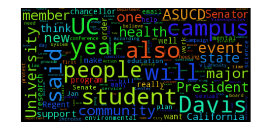

```python
from os import path
from wordcloud import WordCloud
wordcloud = WordCloud(max_font_size=40).generate(''.join(campus_df['text']))
plt.figure()
plt.imshow(wordcloud)
plt.axis("off")
plt.show()
```

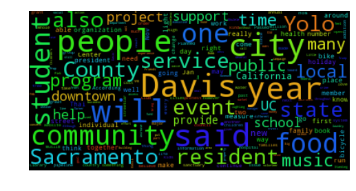

```python
wordcloud = WordCloud(max_font_size=40).generate(''.join(city_df['text']))
plt.figure()
plt.imshow(wordcloud)
plt.axis("off")
plt.show()
```

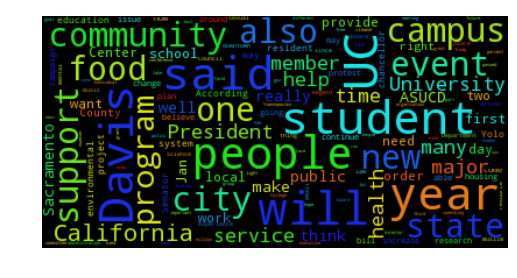

```python
wordcloud = WordCloud(max_font_size=40).generate(''.join(news['text']))
plt.figure()
plt.imshow(wordcloud)
plt.axis("off")
plt.show()
```

In this question, I define a function called interest_topics, which takes a list of files and returns words that ordered from high frequency to low frequency among all the files, and the words that returned do not include punctuations and easy words that in stopwords.words('english').

From the frequency words that in both campus and city news, we can see that "uc davis", "chancellor", "research", "program", "policy", "money", "science", "health", "faculty", "department", "project" always appear, and I think maybe Aggie covers topics most like uc davis research funding policy, uc davis student campus life, uc davis student health and uc davis academic programs and research.

I also extract frequency words for campus news and city news seperately, and make plots with wordcloud for frequency words. We can see that campus news are more related to education, research, students, science, school and program, however, in city news, words like "community", "state", "residents", "downtown", "business", "family", "environment", "music", "council", which are related more about urban construction and residents life rather than school life. And frequency words in Aggie news are more similar with frequency words in campus news.

**Question 2**

```python
text_list = list(news['text'])
```

```python
vectorizer = TfidfVectorizer(tokenizer=lemmatize,stop_words='english',smooth_idf=True)
tfs = vectorizer.fit_transform(text_list)
sim = tfs.dot(tfs.T)
sim
```

```
<120x120 sparse matrix of type '<type 'numpy.float64'>'
	with 14300 stored elements in Compressed Sparse Row format>
```

```python
similar_text_foreachtext = []
for i in range(0, sim.shape[0]):
    tfs_similarities = linear_kernel(tfs[i:i+1], tfs).flatten()
    related_docs_indices = tfs_similarities.argsort()[-2]
    similar_text= (related_docs_indices, tfs_similarities[related_docs_indices])
    similar_text_foreachtext.append(similar_text)
similar_text_foreachtext
```

```
[(12, 0.16868756305496826),
 (11, 0.34637929697121134),
 (119, 0.18057716587711581),
 (24, 0.51539932957916157),
 (15, 0.24101061091351153),
 (84, 0.33845250205115135),
 (44, 0.31036113992485931),
 (54, 0.24857341807822075),
 (55, 0.33010480201801995),
 (42, 0.37688940834705076),
 (11, 0.28500351658923989),
 (1, 0.34637929697121134),
 (102, 0.46607965523319156),
 (34, 0.70525300193086904),
 (29, 0.46001556439901703),
 (54, 0.25453395230361264),
 (92, 0.3124500188019777),
 (21, 0.20668731634920492),
 (23, 0.199384126574771),
 (6, 0.21243239650261833),
 (63, 0.45483167797769219),
 (35, 0.27221583942847666),
 (31, 0.27671481422500371),
 (37, 0.61392952924384792),
 (3, 0.51539932957916157),
 (44, 0.23117705748098058),
 (15, 0.21243692824434809),
 (11, 0.19487762629848071),
 (35, 0.29484176225924186),
 (14, 0.46001556439901703),
 (1, 0.10370664729207159),
 (29, 0.34899972181266647),
 (15, 0.13627540775892422),
 (86, 0.13010029527061825),
 (13, 0.70525300193086904),
 (28, 0.29484176225924186),
 (15, 0.14488886104985149),
 (23, 0.61392952924384792),
 (50, 0.29308263024146097),
 (14, 0.4329290239187395),
```

[output cut: 65 more lines]

```
 (119, 0.2056058310550489),
 (15, 0.17195788618281529),
 (116, 0.37362733625691702),
 (67, 0.18637850390546681),
 (66, 0.33644089891094725),
 (96, 0.45379668779806653),
 (100, 0.29052437175439799),
 (60, 0.30617528387784038),
 (102, 0.54483768988344283),
 (117, 0.50225676099202943),
 (105, 0.198128891403451),
 (107, 0.37362733625691702),
 (114, 0.50225676099202943),
 (115, 0.14989425613878204),
 (54, 0.24345480418379187)]
```

```python
from operator import itemgetter
sorted_similar = sorted(similar_text_foreachtext, key = itemgetter(1))
sorted_similar
```

```
[(25, 0.074472702513050396),
 (25, 0.080817606114661128),
 (62, 0.085763084220321598),
 (115, 0.096551460246348642),
 (52, 0.10301479854769549),
 (1, 0.10370664729207159),
 (15, 0.11112933187913453),
 (2, 0.11454515916841328),
 (114, 0.11863310003561754),
 (88, 0.123954848707933),
 (86, 0.13010029527061825),
 (71, 0.13099922234934891),
 (101, 0.13550565919719321),
 (15, 0.13627540775892422),
 (15, 0.14488886104985149),
 (115, 0.14989425613878204),
 (62, 0.15826109320571496),
 (93, 0.16013395043633663),
 (114, 0.16338418923168999),
 (42, 0.16632214634572051),
 (12, 0.16868756305496826),
 (15, 0.17195788618281529),
 (95, 0.17349337487785213),
 (75, 0.17349337487785213),
 (110, 0.17724432036403029),
 (119, 0.18057716587711581),
 (67, 0.18637850390546681),
 (78, 0.18655238771447744),
 (83, 0.18804437907234123),
 (44, 0.19143302176607968),
 (11, 0.19487762629848071),
 (88, 0.19589042903402795),
 (76, 0.19589042903402795),
 (105, 0.198128891403451),
 (23, 0.199384126574771),
 (54, 0.20487348669295335),
 (114, 0.20547275235901588),
 (119, 0.2056058310550489),
 (21, 0.20668731634920492),
 (60, 0.20897820347333682),
```

[output cut: 65 more lines]

```
 (29, 0.46001556439901703),
 (14, 0.46001556439901703),
 (102, 0.46607965523319156),
 (117, 0.50225676099202943),
 (114, 0.50225676099202943),
 (24, 0.51539932957916157),
 (3, 0.51539932957916157),
 (113, 0.54483768988344283),
 (102, 0.54483768988344283),
 (57, 0.58247409047980014),
 (50, 0.58247409047980014),
 (37, 0.61392952924384792),
 (23, 0.61392952924384792),
 (34, 0.70525300193086904),
 (13, 0.70525300193086904)]
```

```python
sorted_similar[-6:]
```

```
[(57, 0.58247409047980014),
 (50, 0.58247409047980014),
 (37, 0.61392952924384792),
 (23, 0.61392952924384792),
 (34, 0.70525300193086904),
 (13, 0.70525300193086904)]
```

```python
news['text'][13]
```

```
u'Conference entails full day of speakers, panels, student-led discussionsUC Davis held its first mental health conference at the UC Davis Conference Center from 9 a.m. to 7:30 p.m. on Sunday Feb. 7. Over 150 students participated in a series of workshops, panel sets and activities. After check-in a…
```

```python
news['text'][34]
```

```
u'Conference aims to destigmatize mental health, inspire students to engage in mental health workUC Davis will host its first ever mental health conference at the UC Davis Conference Center from 9 a.m. to 8 p.m. on Feb. 5. The UC Davis Mental Health Conference "aims to engage students in destigmatiz…
```

```python
news['text'][23]
```

```
u'Regents approve tuition increase in 16-4 voteThe Regents of the University of California (UC) met at UC San Francisco at Mission Bay on Jan. 25 and 26, approving the first tuition increase for the UC system in six years. Although other business items were discussed at the meeting, tuition dominate…
```

```python
news['text'][37]
```

```
u'Tuition to increase by $336On Thursday, Jan. 26, the UC Regents voted to raise the tuition for all of the 10 UC campuses. The 2017-18 tuition will increase by $282 and the student services fee will increase by $54 \u2014 a $336 increase overall. It will be the first tuition increase since 2010."It…
```

```python
news['text'][50]
```

```
u'Some activists in favor of Yiannopoulos, others accuse speaker of fascismOn Jan. 13, the controversial ultra-conservative speaker Milo Yiannopoulos was to speak at UC Davis as part of his "The Dangerous Faggot Tour" with guest pharmaceutical executive Martin Shkreli. The event, hosted by the Davis…
```

```python
news['text'][57]
```

```
u'Yiannopoulos explains event\'s cancellation, marches with students, community membersA protest was held at the Memorial Union (MU) on Jan. 14 in response to the cancellation of the Milo Yiannopoulos speaking event the night before. The Yiannopoulos event, which had faced backlash from the campus c…
```

I use similarity matrix to find top three most similar pairs of news, and the pairs of news I find are (13, 34), (23, 37) and (50, 57). I compare the text for each pair of news, the first pair of news are both related conference in UC Davis Conference Center, the second pair of news are both relate to tuition in UC system and the third pair of news are both about Yiannopoulos. As a result, the similarity matrix gives the correct results.

```python
def common_special_words(text1, text2):
    intersection = set(text1.lower().split()) & set(text2.lower().split())
    return [w for w in intersection if (w.isalpha()) and (w not in stopwords.words('english'))]
```

```python
common_special_words(news['text'][13], news['text'][34])
```

```
[u'help',
 u'founder',
 u'text',
 u'workshops',
 u'planning',
 u'involved',
 u'suicide',
 u'based',
 u'application',
 u'personal',
 u'disability',
 u'lgbtqia',
 u'forbes',
 u'choose',
 u'gender',
 u'spiritual',
 u'mental',
 u'people',
 u'beyond',
 u'really',
 u'attendees',
 u'attend',
 u'selected',
 u'health',
 u'porter',
 u'body',
 u'full',
 u'opening',
 u'panelists',
 u'juliet',
 u'healing',
 u'groups',
 u'come',
 u'panel',
 u'engage',
 u'davis',
 u'first',
 u'secure',
 u'two',
 u'crisis',
```

[output cut: 17 more lines]

```
 u'place',
 u'monica',
 u'students',
 u'samantha',
 u'director',
 u'student',
 u'funding',
 u'opportunity',
 u'center',
 u'performances',
 u'well',
 u'academic',
 u'advocates',
 u'english',
 u'chiang']
```

```python
common_special_words(news['text'][23], news['text'][37])
```

```
[u'among',
 u'regent',
 u'gavin',
 u'hook',
 u'president',
 u'crisis',
 u'lee',
 u'since',
 u'increase',
 u'regents',
 u'voted',
 u'increasing',
 u'public',
 u'higher',
 u'newsom',
 u'increased',
 u'students',
 u'tuition',
 u'california',
 u'student',
 u'alex',
 u'services',
 u'let',
 u'uc',
 u'first']
```

```python
common_special_words(news['text'][50], news['text'][57])
```

```
[u'words',
 u'held',
 u'violent',
 u'milo',
 u'going',
 u'black',
 u'local',
 u'protesters',
 u'facebook',
 u'protest',
 u'went',
 u'page',
 u'people',
 u'college',
 u'event',
 u'said',
 u'outside',
 u'free',
 u'hundreds',
 u'wanted',
 u'dcr',
 u'great',
 u'davis',
 u'cancellation',
 u'feel',
 u'cancel',
 u'would',
 u'support',
 u'due',
 u'start',
 u'lot',
 u'republicans',
 u'protesting',
 u'matter',
 u'cancelled',
 u'property',
 u'minutes',
 u'uc',
 u'claim',
 u'campus',
 u'damage',
 u'also',
 u'speech',
 u'students',
 u'sacramento',
 u'yiannopoulos',
 u'coming',
 u'america',
 u'time',
 u'came']
```

I define a function called common_special_words that can take two texts and return common words of them. For the first pair, the common words are "help", "founder", "text", "workshops", "planning", "conference", "samantha" and so on. For the second pair, the common words are "among", "regent", "gavin", "hook", "president", "tuition", "student" and so on. For the third pair, the common words are "words", "held", "violent", "milo", "facebook", "yiannopoulos", "sacremento" and so on.

**Question 3**

[figure not shown]

```python
wordcloud = WordCloud(max_font_size=40).generate(''.join(news['text']))
plt.figure()
plt.imshow(wordcloud)
plt.axis("off")
plt.show()
```

I make a wordcloud plot with the text in Aggie news and I find that the highlight words are UC, Davis, student, community, service, public, campus, program, food, health, event, and I think they can represent news both for city and campus, thus Aggie news. However, since the number of articles is so small that maybe they cannot represent all articles in Aggie news.

From this corpus, I can make inferences that the corpus is mainly about topics like school life of UC Davis students, research funding, research topics, academic programs, city life of residents in Sacramento, health issues for both students and city residents, since words like UC Davis, students, community, service, public, campus, program, food, health appear more frequently in this corpus.